# VAR e Projeção Local: política monetária nos EUA

UFMG – Econometria das Séries Temporais Aplicada à Macroeconomia e Finanças · Prof. Mauro Sayar Ferreira · Lista 6 (entrega em 05/11/2026)  
Dados do FRED, mensais, 1990-01 a 2007-12 (216 observações; 212 efetivas no VAR) · Python (numpy, statsmodels)

**Resumo.** Estima-se um VAR(4) **com todas as variáveis em nível** (logaritmos de produção industrial, CPI e preços de commodities, taxa de desemprego e Fed Funds), com identificação recursiva (Cholesky), para a amostra de 1990 a 2007. Um choque monetário de 100 pontos-base eleva o juro a cerca de 1,75 p.p. em seis meses e é seguido, no curto prazo, de aumento significativo da produção e das commodities e de queda do desemprego, sinais contrários à teoria. O CPI sobe, mas sem significância no VAR. A projeção local reproduz o padrão (com CPI significativo). Conclui-se que o principal problema é de identificação, e não de método. Todas as figuras, tabelas e o código completo constam deste documento.

## A. Fase preparatória

1) Motivação econômica. O trabalho trata da transmissão da política monetária americana. A relação conjunta entre as variáveis decorre de três blocos: (i) a **regra de Taylor**, $i_t=r^*+\pi_t+\phi_\pi(\pi_t-\pi^*)+\phi_y\tilde y_t$, que descreve a reação do Fed à inflação e à atividade; (ii) uma **curva IS**, pela qual a taxa de juros afeta a demanda e, com ela, a produção e o desemprego; e (iii) uma **curva de Phillips**, pela qual a demanda afeta os preços, sempre com defasagens. Daí a escolha de variáveis de atividade (produção industrial e desemprego), de preços (CPI) e do instrumento (Fed Funds, taxa efetiva). Inclui-se também o índice de preços ao produtor de todas as commodities (PPIACO), que antecipa pressões inflacionárias observadas pelo Fed e ajuda a mitigar o *price puzzle* (Sims, 1992). Cabe notar que o PPIACO é um índice amplo de preços ao produtor, e não um índice puro de commodities, como o CRB.

**Amostra.** Estima-se o modelo de janeiro de 1990 a dezembro de 2007 (216 observações). A amostra exclui o período de juro próximo de zero (dezembro de 2008 a dezembro de 2015), no qual o instrumento fica praticamente imóvel e a política é conduzida por compra de ativos e *forward guidance*, o que torna a equação do juro mal especificada. A amostra completa (1990–2019, 360 observações) é usada apenas como análise de robustez. A taxa sombra de Wu e Xia (2016) seria uma alternativa para incluir o período de juro zero, mas não foi implementada.

2) Séries originais.

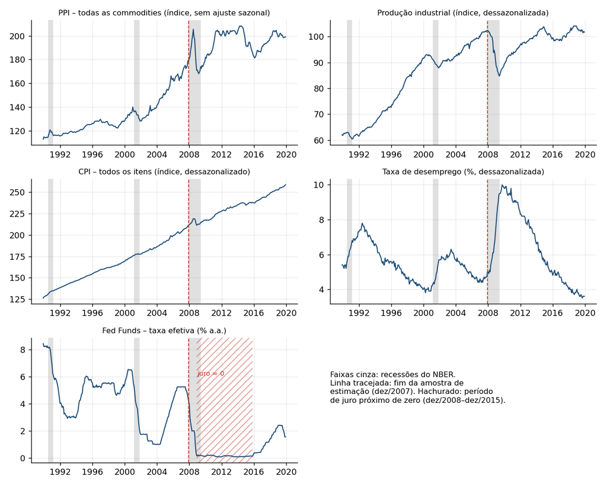

Séries em nível, como baixadas do FRED. Faixas cinza: recessões do NBER; linha tracejada: fim da amostra de estimação; hachurado: período de juro próximo de zero.

3) Ajustes. Produção industrial, CPI e preços de commodities foram logaritmizados ($100\,\ln x_t$); desemprego (%) e Fed Funds (% a.a.) permanecem como na fonte. **Todas as variáveis entram no VAR em nível**: as respostas das variáveis em logaritmo são, portanto, variações percentuais aproximadas em relação ao nível inicial, e as de desemprego e juro estão em pontos percentuais. As séries CPIAUCSL, INDPRO e UNRATE já são dessazonalizadas pela fonte. A série PPIACO **não é dessazonalizada** no FRED; por isso, retirou-se do seu logaritmo a componente sazonal determinística (dummies mensais, controlando por tendência linear) antes da estimação.

Os testes de raiz unitária (H0 do ADF: raiz unitária; H0 do KPSS: estacionariedade) foram aplicados nas séries em nível com a especificação indicada na tabela: constante e tendência para os logaritmos, que são tendenciais, e apenas constante para desemprego e juro. As defasagens do ADF foram escolhidas pelo critério de Akaike (a coluna indica o número selecionado) e o KPSS usa largura de banda automática. Como a tabela de valores críticos do KPSS cobre apenas de 0,01 a 0,10, os p-valores são truncados e aparecem como “≥ 0,10” ou “≤ 0,01”.

| Série em nível | Especificação | ADF (p-valor) | Defasagens ADF | KPSS (p-valor) |
| --- | --- | --- | --- | --- |
| Produção industrial (ln×100) | constante e tendência | 0,920 | 3 | ≤ 0,01 |
| CPI (ln×100) | constante e tendência | 0,800 | 13 | 0,010 |
| Commodities (PPI) (ln×100) | constante e tendência | 0,993 | 15 | ≤ 0,01 |
| Desemprego (%) | constante | 0,336 | 6 | ≤ 0,01 |
| Fed Funds (% a.a.) | constante | 0,039 | 3 | 0,025 |

Os logaritmos de produção, CPI e commodities não rejeitam raiz unitária no ADF e rejeitam estacionariedade no KPSS. O desemprego também não rejeita raiz unitária (ADF) e rejeita estacionariedade a 1% (KPSS); o Fed Funds tem evidência mista (ambos os testes rejeitam a 5%). Em suma, as cinco séries são muito persistentes, com raízes próximas de um. A estimação em nível é válida para fins de resposta ao impulso: Sims, Stock e Watson (1990) mostram que o VAR em nível estima consistentemente as funções de resposta mesmo na presença de raiz unitária ou de cointegração, sem exigir que se conheça a ordem de integração nem as relações de cointegração. O que se perde é a distribuição assintótica padrão de alguns testes, razão pela qual os intervalos de confiança são obtidos por *bootstrap*. A mesma especificação (nível) é aplicada a todas as variáveis, e eventuais relações de cointegração não são impostas.

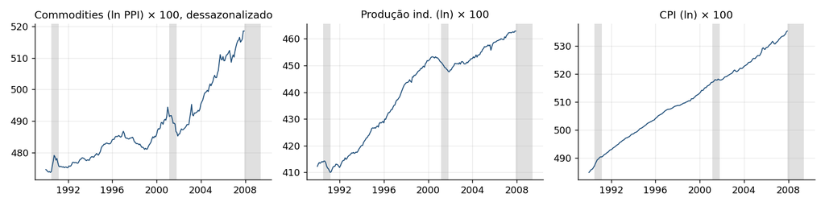

Séries em logaritmo (×100) usadas no VAR; PPI dessazonalizado.

Séries usadas no VAR (logaritmos ×100; PPI dessazonalizado). Desemprego e Fed Funds não sofrem transformação (ver figura do item 2).

## B. VAR em forma reduzida

4) Defasagens e restrições. Estima-se, por mínimos quadrados ordinários equação a equação, $y_t=c+\sum_{k=1}^{p}A_k y_{t-k}+u_t$, $u_t\sim(0,\Sigma_u)$, com $y_t=(ip_t,cpi_t,p^{com}_t,ur_t,ffr_t)'$ (logaritmos de produção, CPI e commodities; desemprego e juro em nível). Os critérios de informação foram calculados para $p=1,\dots,12$ sobre a mesma amostra efetiva, e o teste portmanteau multivariado (24 defasagens) foi aplicado aos resíduos de cada modelo. O critério de Akaike escolhe $p=3$, e os de Schwarz e Hannan-Quinn escolhem $p=2$, porém o portmanteau rejeita a hipótese de resíduos brancos para $p=1,2$ e $3$ (a 5%). O critério adotado é o **menor $p$ cujos resíduos não rejeitam a hipótese de ruído branco**, o que leva a **$p=4$** (p-valor do portmanteau = 0,079). O modelo com $p=6$ é estimado como análise de robustez (para ele, o portmanteau rejeita a 5%, p = 0,043). A amostra efetiva do VAR(4) tem 212 observações (as 4 primeiras são perdidas como valores iniciais).

| p | AIC | BIC | HQ | Portmanteau(24) p-valor |
| --- | --- | --- | --- | --- |
| 1 | −13,351 | −12,864 | −13,154 | < 0,001 |
| 2 | −13,862 | −12,967 | −13,500 | < 0,001 |
| 3 | −13,958 | −12,656 | −13,431 | 0,007 |
| 4 | −13,914 | −12,206 | −13,223 | 0,079 |
| 5 | −13,811 | −11,697 | −12,956 | 0,072 |
| 6 | −13,765 | −11,244 | −12,745 | 0,043 |
| 7 | −13,741 | −10,813 | −12,556 | 0,073 |
| 8 | −13,683 | −10,349 | −12,334 | 0,056 |
| 9 | −13,560 | −9,819 | −12,047 | 0,010 |
| 10 | −13,507 | −9,359 | −11,829 | 0,006 |
| 11 | −13,590 | −9,036 | −11,748 | 0,003 |
| 12 | −13,545 | −8,584 | −11,539 | 0,005 |

Não há restrições de exclusão na forma reduzida: todas as variáveis são domésticas e podem interagir entre si em qualquer defasagem. A parcimônia vem apenas da escolha de $p$.

5) Qualidade do ajuste. As figuras e testes a seguir avaliam se os resíduos estão branqueados.

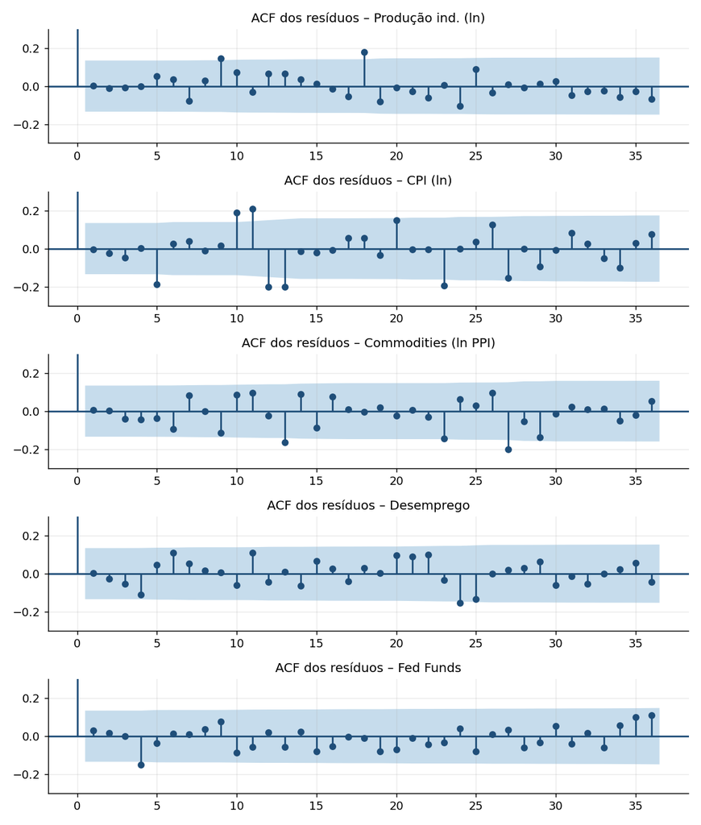

Correlogramas dos resíduos de cada equação (bandas de 95%).

| Equação | Ljung-Box, 12 defasagens (p) | Ljung-Box, 24 defasagens (p) |
| --- | --- | --- |
| Produção industrial | 0,653 | 0,444 |
| CPI | < 0,001 | < 0,001 |
| Commodities (PPI) | 0,489 | 0,222 |
| Desemprego | 0,498 | 0,330 |
| Fed Funds | 0,641 | 0,866 |

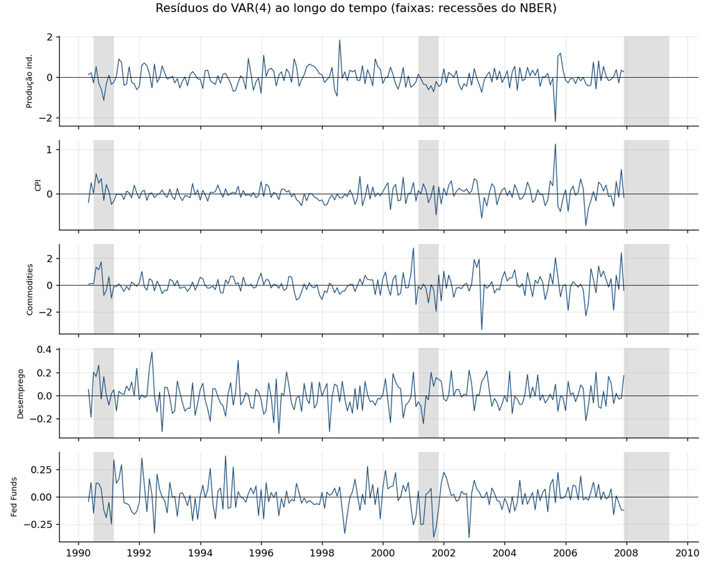

Resíduos ao longo do tempo.

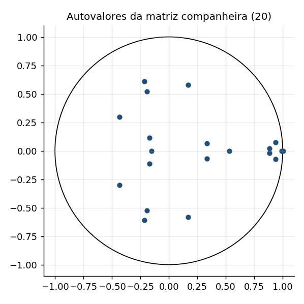

Autovalores da matriz companheira (círculo: raio unitário).

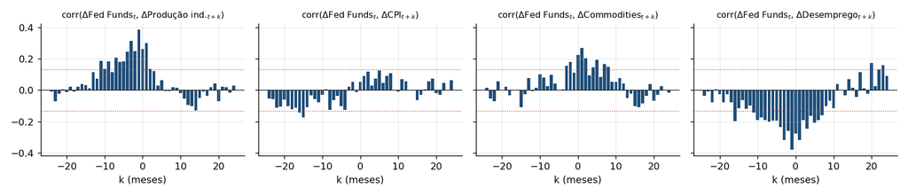

Correlações cruzadas entre o Fed Funds e as demais variáveis (linhas pontilhadas: banda de 95% sob ruído branco).

## C. Análise estrutural

6) Restrições de identificação. A identificação é recursiva (Cholesky): $\Sigma_u=PP'$, com $P$ triangular inferior, $u_t=P\varepsilon_t$ e $\varepsilon_t\sim(0,I)$. Como $\Sigma_u$ tem $n(n+1)/2=15$ elementos distintos e $P$ tem $n^2=25$ elementos, são necessárias $25-15=10$ restrições, que são exatamente os dez zeros acima da diagonal de uma matriz triangular inferior $5\times 5$: a identificação é **exata**. A ordem adotada segue Christiano, Eichenbaum e Evans (1999): produção industrial, CPI, commodities, desemprego e Fed Funds. Isso impõe que: (i) produção e preços ao consumidor, rígidos no curto prazo, não reagem dentro do mês a nenhuma das demais variáveis, e, por isso, são ordenados primeiro; (ii) o preço de commodities, flexível e negociado continuamente, reage dentro do mês à atividade e aos preços ao consumidor, razão pela qual vem depois deles, e o Fed observa seu comportamento corrente; (iii) o desemprego reage dentro do mês à produção e aos preços, mas não ao juro; (iv) o Fed Funds vem **por último**: a política reage contemporaneamente a todas as variáveis (o Fed observa os dados correntes), mas o choque monetário afeta as demais apenas com defasagem de um mês.

Uma propriedade relevante, demonstrada por Christiano, Eichenbaum e Evans (1999), é que, com o juro ordenado por último, a resposta ao **choque monetário** não depende da ordem das quatro primeiras variáveis. As respostas aos **demais** choques e a decomposição da variância, porém, dependem da ordem; isso é verificado na análise de robustez.

7a) Funções de resposta ao impulso (FRI). A figura apresenta a resposta de cada variável (linhas) a cada choque estrutural (colunas) de um desvio-padrão, com intervalos de confiança de 90%. As variáveis estão em nível: as respostas dos logaritmos são variações percentuais aproximadas, e as de desemprego e juro, pontos percentuais. Cada linha usa a mesma escala vertical. Os desvios-padrão dos choques (impacto sobre a própria variável) são, em % para os logaritmos e em p.p. para desemprego e juro:

|  | Produção industrial | CPI | Commodities (PPI) | Desemprego | Fed Funds |
| --- | --- | --- | --- | --- | --- |
| 1 desvio-padrão | 0,48 | 0,20 | 0,55 | 0,12 | 0,13 |

**Intervalos de confiança.** Utiliza-se o *bootstrap* *wild* (multiplicador de Rademacher aplicado ao vetor de resíduos, que preserva a heterocedasticidade e a correlação contemporânea), em linha com a rejeição da normalidade e a presença de caudas pesadas. Geram-se 1000 séries a partir do modelo estimado, reestima-se o VAR e recalculam-se as funções de resposta; os intervalos de 90% são os percentis 5% e 95% das réplicas. O procedimento inclui a correção de viés de Kilian (1998), que se aplica apenas quando o modelo estimado é estável; como a maior raiz por MQO é 1,003 (≥ 1), a correção não é acionada e as estimativas pontuais são as de MQO. Esse é o caso esperado em VAR em nível com variáveis integradas, no qual o viés de pequena amostra é potencialmente relevante e os intervalos devem ser lidos com cautela, sobretudo nos horizontes longos.

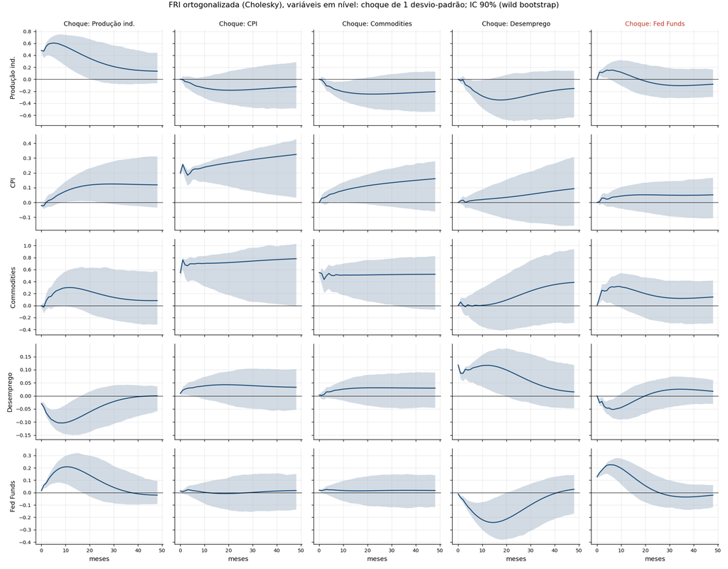

Matriz 5×5: linhas = variável que responde; colunas = choque. IC 90% por *wild bootstrap*.

7b) Interpretação. A resposta ao **choque monetário** é apresentada para um aumento de **100 pontos-base** (1 p.p.) no Fed Funds no impacto, escala que permite a comparação direta com a projeção local do item 9. Choques de 1 desvio-padrão correspondem a apenas 13 pontos-base e produziriam números pouco legíveis.

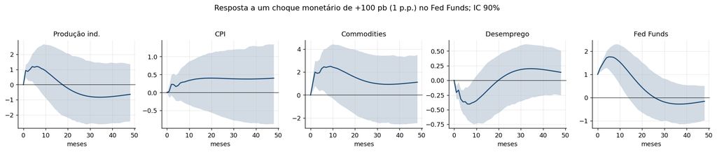

Resposta a +100 pb de choque monetário (IC 90%).

| Resposta ao choque de +100 pb (% ou p.p.) | h=0 | h=6 | h=12 | h=24 | h=48 |
| --- | --- | --- | --- | --- | --- |
| Produção industrial | 0,00 [0,00; 0,00] | 1,20 [−0,14; 2,40] | 0,67 [−1,21; 2,60] | −0,55 [−2,46; 1,86] | −0,64 [−2,41; 1,36] |
| CPI | 0,00 [0,00; 0,00] | 0,27 [−0,22; 0,65] | 0,37 [−0,40; 0,92] | 0,40 [−0,65; 1,16] | 0,40 [−0,87; 1,35] |
| Commodities (PPI) | 0,00 [0,00; 0,00] | 2,45 [0,35; 4,00] | 2,32 [−0,62; 4,38] | 1,25 [−2,05; 3,69] | 1,12 [−2,44; 3,51] |
| Desemprego | 0,00 [0,00; 0,00] | −0,40 [−0,68; −0,12] | −0,28 [−0,73; 0,17] | 0,10 [−0,43; 0,51] | 0,14 [−0,25; 0,51] |
| Fed Funds | 1,00 [1,00; 1,00] | 1,75 [1,10; 2,21] | 1,32 [0,23; 2,16] | 0,10 [−0,86; 1,18] | −0,16 [−0,98; 0,51] |

**Demais choques** (ver matriz 5×5; os choques de 1 desvio-padrão, com identificação apenas recursiva, não têm todos nome econômico claro):

- **Choque de produção industrial** (demanda ou oferta agregada, sem distinção nesta identificação): a produção sobe de forma persistente (0,51 [0,17; 0,73] em 12 meses), o desemprego cai (−0,10 [−0,15; −0,02]) e o Fed Funds sobe (0,21 [0,05; 0,31]), reação endógena da política à atividade, em linha com a regra de Taylor.
- **Choque de CPI** (choque de preço doméstico, por exemplo de *markup* ou de custos, com efeito permanente sobre o nível de preços): o CPI sobe no impacto e permanece alto (0,24 [0,13; 0,28]); o desemprego e o Fed Funds não reagem de forma significativa (0,04 [−0,02; 0,08] e −0,00 [−0,10; 0,09]).
- **Choque de commodities** (aumento do preço de insumos, condicional à atividade e ao CPI): o repasse ao CPI é pequeno (0,09 [−0,00; 0,15]); a produção cai (−0,22 [−0,39; −0,03]), compatível com choque de oferta adverso; o Fed Funds não reage (0,01 [−0,08; 0,10]).
- **Choque de desemprego** (variação da taxa de desemprego não explicada por produção, preços e commodities; não tem interpretação estrutural limpa nesta identificação, podendo refletir choque de oferta de trabalho, de pareamento ou de ciclo de emprego): o Fed Funds cai (−0,24 [−0,33; −0,07] em 12 meses), como numa regra de Taylor com peso no desemprego; a resposta das commodities não é significativa (0,01 [−0,38; 0,34]).
- Os choques de **CPI e de desemprego** não têm identificação estrutural nítida; a rotulagem acima é apenas indicativa. Somente o choque monetário (último na ordem) tem interpretação estrutural direta.

8) Decomposição da variância do erro de previsão (FEVD). Percentual da variância do erro de previsão de cada variável (linhas) atribuído a cada choque (colunas) em 12, 24 e 48 meses (1, 2 e 4 anos). A ordem é a mesma do item 6.

### 1 ano

| Variável \ choque | Produção industrial | CPI | Commodities (PPI) | Desemprego | Fed Funds |
| --- | --- | --- | --- | --- | --- |
| Produção industrial | 79,5 | 2,4 | 5,6 | 8,5 | 4,1 |
| CPI | 4,0 | 87,7 | 6,2 | 0,3 | 1,8 |
| Commodities (PPI) | 5,4 | 55,6 | 30,4 | 0,0 | 8,5 |
| Desemprego | 35,0 | 4,5 | 1,6 | 51,1 | 7,8 |
| Fed Funds | 28,3 | 0,2 | 0,4 | 26,3 | 44,8 |

### 2 anos

| Variável \ choque | Produção industrial | CPI | Commodities (PPI) | Desemprego | Fed Funds |
| --- | --- | --- | --- | --- | --- |
| Produção industrial | 62,7 | 5,4 | 10,4 | 19,1 | 2,4 |
| CPI | 9,4 | 77,7 | 9,7 | 0,8 | 2,3 |
| Commodities (PPI) | 6,6 | 56,2 | 29,6 | 0,4 | 7,3 |
| Desemprego | 31,8 | 6,6 | 3,0 | 53,7 | 4,9 |
| Fed Funds | 29,7 | 0,1 | 0,3 | 41,5 | 28,4 |

### 4 anos

| Variável \ choque | Produção industrial | CPI | Commodities (PPI) | Desemprego | Fed Funds |
| --- | --- | --- | --- | --- | --- |
| Produção industrial | 49,5 | 8,1 | 16,7 | 22,5 | 3,3 |
| CPI | 10,6 | 71,6 | 13,2 | 2,5 | 2,0 |
| Commodities (PPI) | 3,9 | 57,8 | 28,7 | 5,2 | 4,4 |
| Desemprego | 26,8 | 10,5 | 5,9 | 50,9 | 5,8 |
| Fed Funds | 28,5 | 0,2 | 0,6 | 44,3 | 26,4 |

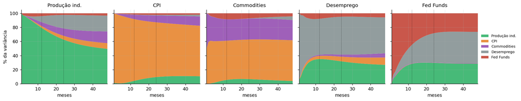

FEVD por horizonte (linhas pontilhadas: 12, 24 e 48 meses).

**Comentários.**

- **Choques próprios** dominam no curto prazo em produção (79% em 1 ano), CPI (88%) e desemprego (51%), mas perdem peso no horizonte de 4 anos em produção (49%) e CPI (72%), pois as variáveis em nível acumulam efeitos de outros choques. O Fed Funds é explicado por seu próprio choque em 45% em 1 ano e 26% em 4 anos; no horizonte longo, passam a explicá-lo os choques de desemprego (44%) e de produção (28%), coerente com uma regra de Taylor.
- **Resultados dependentes da ordem.** Na ordem adotada, os choques de commodities respondem por apenas 6% da variância do CPI em 1 ano, ao passo que os choques de CPI explicam 56% da variância das commodities. Na ordem alternativa (commodities primeiro), a relação se inverte: 68% da variância do CPI é atribuída a commodities. A correlação contemporânea entre os dois resíduos é alocada pela ordenação, e essas parcelas não devem ser lidas como causalidade econômica.
- **Desemprego:** os choques de produção explicam 35% da variância em 1 ano e 27% em 4 anos, resultado compatível com a lei de Okun, mas em parte mecânico: a produção precede o desemprego na ordem (em ambas as ordens testadas), de modo que a correlação contemporânea entre os dois resíduos é atribuída ao choque de produção.
- **Choque monetário:** explica pouco das demais variáveis (entre 2% e 6% em 4 anos): a maior parte da variação do juro é resposta sistemática, e não inovação.

## D. Projeção local

9) Estimação e estratégia de identificação. A **variável mais endógena** do sistema é o **Fed Funds**, que, por ser a última na ordem recursiva, é a única que sofre impacto contemporâneo de todas as demais. Estima-se, por projeção local (Jordà, 2005), a equação do Fed Funds para cada horizonte $h=0,1,\dots,12$: $$ffr_{t+h}=\alpha_h+\beta_h\,x_t+\gamma_h'\,w_t+\sum_{k=1}^{4}\delta_{h,k}'\,y_{t-k}+e^{(h)}_{t+h},$$ em que $x_t\in\{ip_t,cpi_t,p^{com}_t,ur_t\}$ (em nível) é a variável cuja inovação constitui o choque e $w_t$ reúne os valores **contemporâneos** das variáveis ordenadas **antes** de $x_t$. Assim, $\beta_0$ mede o **impacto contemporâneo** sobre o juro e é diferente de zero (a equação é uma regra de Taylor dinâmica estimada por projeção local), e $\beta_h$ ($h=1,\dots,12$) traça a trajetória subsequente.

**Identificação.** Utiliza-se a mesma recursividade do VAR: ao controlar pelas defasagens de todas as variáveis e pelos valores contemporâneos das variáveis ordenadas antes de $x_t$, a variação remanescente de $x_t$ é a inovação (ortogonal ao conjunto de informação anterior na ordem de Cholesky). Os coeficientes têm, portanto, a mesma interpretação das FRI do VAR para um choque de 1 unidade (1% nas variáveis em logaritmo; 1 p.p. em desemprego) na variável $x_t$. Nesta ordem, a produção industrial é a primeira variável; logo, para o choque de produção, $w_t$ é vazio e $\beta_0=P_{5,1}/P_{1,1}$.

10) Resultados. Os intervalos de confiança de 90% são $\hat\beta_h\pm1{,}645\,\widehat{se}$, com erros-padrão **robustos à heterocedasticidade** (Eicker-Huber-White, HC1), como pede o enunciado. A inclusão de defasagens suficientes de controle torna esses erros-padrão adequados, com melhor cobertura que o estimador de Newey-West em amostras finitas (Montiel Olea e Plagborg-Møller, 2021). Como verificação, os erros de Newey-West resultaram entre 84% e 94% dos erros EHW.

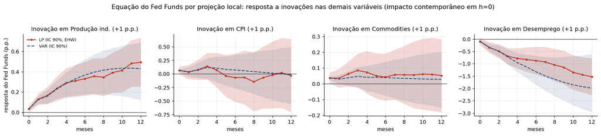

Equação do Fed Funds por projeção local, h = 0 a 12: resposta a inovações de +1 unidade em cada variável (IC 90%, erros robustos à heterocedasticidade), comparada ao VAR.

| Resposta do Fed Funds (p.p.) | h=0 | h=1 | h=3 | h=6 | h=9 | h=12 |
| --- | --- | --- | --- | --- | --- | --- |
| Inovação em Produção industrial | 0,03 [0,00; 0,06] | 0,13 [0,08; 0,18] | 0,24 [0,11; 0,36] | 0,33 [0,16; 0,50] | 0,39 [0,19; 0,59] | 0,49 [0,25; 0,73] |
| Inovação em CPI | 0,06 [−0,01; 0,14] | 0,03 [−0,10; 0,16] | 0,14 [−0,11; 0,38] | −0,07 [−0,51; 0,37] | −0,07 [−0,64; 0,50] | −0,03 [−0,71; 0,64] |
| Inovação em Commodities (PPI) | 0,04 [0,00; 0,07] | 0,03 [−0,02; 0,09] | 0,08 [−0,02; 0,19] | 0,04 [−0,11; 0,19] | 0,06 [−0,16; 0,27] | 0,05 [−0,18; 0,28] |
| Inovação em Desemprego | −0,09 [−0,24; 0,05] | −0,34 [−0,57; −0,12] | −0,70 [−1,03; −0,36] | −0,87 [−1,43; −0,32] | −1,15 [−1,82; −0,47] | −1,53 [−2,27; −0,78] |
| Inovação em Produção industrial (VAR) | 0,03 | 0,13 | 0,23 | 0,37 | 0,43 | 0,43 |
| Inovação em CPI (VAR) | 0,06 | 0,04 | 0,12 | 0,07 | 0,03 | −0,01 |
| Inovação em Commodities (PPI) (VAR) | 0,04 | 0,03 | 0,05 | 0,04 | 0,03 | 0,03 |
| Inovação em Desemprego (VAR) | −0,09 | −0,34 | −0,73 | −1,33 | −1,75 | −1,99 |

**Leitura.** O impacto contemporâneo é diferente de zero e economicamente pequeno: uma inovação de 1% na produção eleva o juro em 0,03 p.p. no mesmo mês, e o efeito cresce até 0,49 p.p. em 12 meses (intervalo [0,25; 0,73]). Um aumento inesperado de 1 p.p. no desemprego reduz o juro de forma persistente (−1,53 p.p. em 12 meses), em linha com a regra de Taylor, ao passo que as inovações de CPI e de commodities não têm efeito significativo sobre o juro após o impacto. As estimativas por projeção local e por VAR (linha tracejada) são próximas, com intervalos da LP mais largos, como esperado de um estimador menos restrito.

Complemento: resposta a uma inovação monetária. Para comparação com o VAR, estima-se também o choque monetário por projeção local, com $ffr_t$ como regressor e controle pelos valores contemporâneos de todas as demais variáveis (todas ordenadas antes dele) e 4 defasagens. Por construção, o efeito contemporâneo nas demais variáveis é nulo, e sobre o próprio juro, igual a 1.

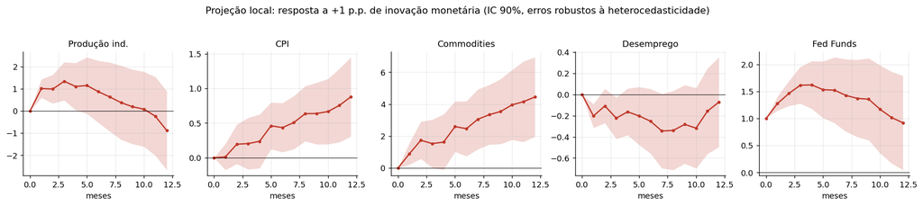

Projeção local: resposta a +1 p.p. de inovação monetária (IC 90%).

| Resposta (p.p.) | h=0 | h=1 | h=3 | h=6 | h=9 | h=12 |
| --- | --- | --- | --- | --- | --- | --- |
| Produção industrial | 0,00 [0,00; 0,00] | 1,01 [0,60; 1,43] | 1,34 [0,48; 2,20] | 0,87 [−0,53; 2,27] | 0,19 [−1,49; 1,87] | −0,88 [−2,66; 0,90] |
| CPI | 0,00 [0,00; 0,00] | 0,01 [−0,18; 0,20] | 0,20 [−0,17; 0,58] | 0,44 [0,08; 0,79] | 0,64 [0,19; 1,08] | 0,88 [0,31; 1,45] |
| Commodities (PPI) | 0,00 [0,00; 0,00] | 0,90 [0,22; 1,58] | 1,53 [0,02; 3,04] | 2,46 [0,74; 4,19] | 3,54 [1,51; 5,58] | 4,45 [1,96; 6,94] |
| Desemprego | 0,00 [0,00; 0,00] | −0,20 [−0,32; −0,09] | −0,22 [−0,42; −0,03] | −0,25 [−0,56; 0,05] | −0,28 [−0,65; 0,09] | −0,07 [−0,50; 0,35] |
| Fed Funds | 1,00 [1,00; 1,00] | 1,28 [1,15; 1,41] | 1,61 [1,28; 1,95] | 1,52 [0,92; 2,13] | 1,36 [0,60; 2,11] | 0,92 [0,05; 1,79] |

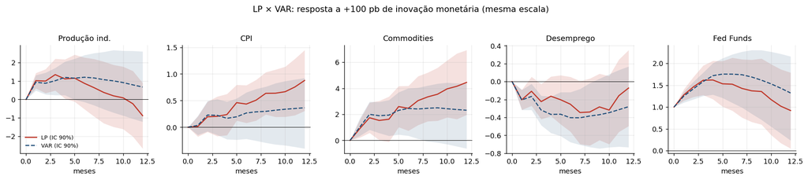

Comparação LP × VAR, mesma escala (+100 pb).

**Leitura.** Uma inovação de 1 p.p. no Fed Funds chega a cerca de 1,5 p.p. nos primeiros meses e permanece acima do valor inicial por cerca de um ano: 0,92 p.p. após 12 meses (VAR: 1,32), padrão de política sistemática. O CPI sobe 0,88 % em 12 meses (intervalo [0,31; 1,45]) e as commodities sobem 4,45 % (intervalo [1,96; 6,94]): puzzles significativos, coerentes com o efeito informacional. O desemprego cai de forma significativa no primeiro mês (−0,20 p.p., intervalo [−0,32; −0,09]), e a produção sobe com defasagem e perde significância em seguida. A LP reproduz, portanto, os puzzles do VAR e torna o do CPI estatisticamente significativo.

## Robustez

A resposta ao choque monetário (+100 pb) é comparada em quatro especificações: a principal; a ordem alternativa, com commodities antes de produção e CPI; o VAR(6); e a amostra completa 1990–2019 (com o período de juro zero).

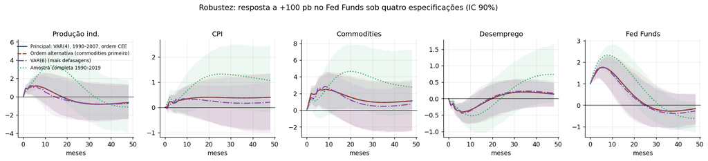

Resposta ao choque monetário (+100 pb) em quatro especificações.

| Resposta em h=12 | Produção industrial | CPI | Commodities (PPI) | Desemprego | Fed Funds |
| --- | --- | --- | --- | --- | --- |
| Principal: VAR(4), 1990–2007, ordem CEE | 0,67 | 0,37 | 2,32 | −0,28 | 1,32 |
| Ordem alternativa (commodities primeiro) | 0,67 | 0,37 | 2,32 | −0,28 | 1,32 |
| VAR(6) (mais defasagens) | 0,27 | 0,32 | 2,38 | −0,28 | 1,22 |
| Amostra completa 1990–2019 | 3,36 | 0,82 | 3,58 | −0,51 | 2,16 |

A ordem alternativa reproduz exatamente a mesma resposta ao choque monetário, como previsto pela invariância à ordem das variáveis anteriores ao juro (Christiano, Eichenbaum e Evans, 1999). O VAR(6) mantém o mesmo padrão qualitativo, com resposta menor da produção (0,27 contra 0,67 % em 12 meses). A amostra completa gera respostas maiores de produção e commodities (produção: 3,36 %), o que reforça a decisão de excluir o período de juro zero da estimação principal. A decomposição da variância, ao contrário, **não** é robusta à ordem (item 8). Para referência, a FEVD na ordem alternativa a 1 ano:

| Variável \ choque | Commodities (PPI) | Produção industrial | CPI | Desemprego | Fed Funds |
| --- | --- | --- | --- | --- | --- |
| Commodities (PPI) | 83,7 | 5,6 | 2,1 | 0,0 | 8,5 |
| Produção industrial | 7,9 | 79,2 | 0,3 | 8,5 | 4,1 |
| CPI | 68,1 | 4,1 | 25,6 | 0,3 | 1,8 |
| Desemprego | 5,8 | 34,8 | 0,5 | 51,1 | 7,8 |
| Fed Funds | 0,6 | 28,3 | 0,0 | 26,3 | 44,8 |

## Conclusão

Com identificação recursiva e variáveis em nível, o VAR e a projeção local produzem respostas qualitativamente iguais: um “choque” monetário de 100 pb eleva o juro a cerca de 1,5 a 1,8 p.p. nos primeiros meses e é acompanhado, no curto prazo, de aumento de produção e de commodities, queda do desemprego e alta de preços (esta significativa na projeção local e não significativa no VAR). O fato de dois estimadores distintos chegarem a respostas semelhantes indica que **o problema é de identificação, e não de método** (Plagborg-Møller e Wolf, 2021), isto é, o choque recursivo mistura inovação exógena com a reação sistemática do Fed a informação não observada pelo modelo. A equação do juro por projeção local confirma a reação sistemática do Fed (juro sobe com a produção, cai com o desemprego). Para obter efeitos monetários com sinais corretos seria necessário usar choques narrativos ou de alta frequência. Limitações assumidas: resíduo sazonal na equação do CPI, caudas pesadas, raiz maior que 1 no VAR em nível (sem correção de viés) e exclusão do período de juro zero.

## Referências

1. Christiano, L., Eichenbaum, M., Evans, C. (1999). Monetary Policy Shocks: What Have We Learned and to What End? *Handbook of Macroeconomics*.
2. Jarociński, M., Karadi, P. (2020). Deconstructing Monetary Policy Surprises. *AEJ: Macroeconomics*.
3. Jordà, Ò. (2005). Estimation and Inference of Impulse Responses by Local Projections. *AER*.
4. Kilian, L. (1998). Small-Sample Confidence Intervals for Impulse Response Functions. *REStat*.
5. Montiel Olea, J. L., Plagborg-Møller, M. (2021). Local Projection Inference Is Simpler and More Robust Than You Think. *Econometrica*.
6. Nakamura, E., Steinsson, J. (2018). High-Frequency Identification of Monetary Non-Neutrality: The Information Effect. *QJE*.
7. Plagborg-Møller, M., Wolf, C. (2021). Local Projections and VARs Estimate the Same Impulse Responses. *Econometrica*.
8. Romer, C., Romer, D. (2000). Federal Reserve Information and the Behavior of Interest Rates. *AER*.
9. Sims, C. (1992). Interpreting the macroeconomic time series facts: the effects of monetary policy. *European Economic Review*.
10. Sims, C., Stock, J., Watson, M. (1990). Inference in Linear Time Series Models with Some Unit Roots. *Econometrica*.
11. Wu, J. C., Xia, F. D. (2016). Measuring the Macroeconomic Impact of Monetary Policy at the Zero Lower Bound. *JMCB*.

## Código e reprodução

O código abaixo é o **código completo** usado em todas as estimações, figuras e tabelas (`analise.py`); o segundo bloco é o gerador deste documento (`build_html.py`). Os dados vêm do FRED (PPIACO, INDPRO, CPIAUCSL, UNRATE, FEDFUNDS) e ficam na pasta `data/`. Reprodução: `python analise.py && python build_html.py` (sementes fixas).

**analise.py – dados, VAR, bootstrap, FRI, FEVD, projeção local e figuras**

```
"""Lista 6 - VAR e Projecao Local: politica monetaria nos EUA (FRED, mensal).

Amostra principal: 1990-01 a 2007-12 (antes do limite inferior zero da taxa de juros).
Robustez: amostra completa 1990-2019 e ordenacao alternativa de Cholesky.
Execucao: python analise.py   (gera img/*.png e resultados.json)
"""
import json, os, warnings
import numpy as np, pandas as pd
import matplotlib
matplotlib.use("Agg")
import matplotlib.pyplot as plt
import statsmodels.api as sm
from statsmodels.tsa.api import VAR
from statsmodels.tsa.stattools import adfuller, kpss
from statsmodels.stats.diagnostic import acorr_ljungbox
from statsmodels.graphics.tsaplots import plot_acf

warnings.filterwarnings("ignore")
HERE = os.path.dirname(os.path.abspath(__file__))
os.makedirs(f"{HERE}/img", exist_ok=True)
SEED, P_LAGS, H_IRF, H_LP = 12345, 4, 48, 12
END_MAIN, END_FULL = "2007-12-01", "2019-12-01"
N_BOOT, N_BOOT_BIAS = 1000, 500
plt.rcParams.update({"figure.dpi": 130, "axes.spines.top": False, "axes.spines.right": False,
                     "axes.grid": True, "grid.alpha": .25, "font.size": 10, "axes.titlesize": 11})
C1, C2, C3 = "#1f4e79", "#c0392b", "#7f8c8d"
RECESSIONS = [("1990-07", "1991-03"), ("2001-03", "2001-11"), ("2007-12", "2009-06")]   # datacao do NBER

# ------------------------------------------------------------------ dados
FRED = {"PPIACO": "PPI – todas as commodities (índice, sem ajuste sazonal)",
        "INDPRO": "Produção industrial (índice, dessazonalizada)",
        "CPIAUCSL": "CPI – todos os itens (índice, dessazonalizado)",
        "UNRATE": "Taxa de desemprego (%, dessazonalizada)",
        "FEDFUNDS": "Fed Funds – taxa efetiva (% a.a.)"}


def load(s):
    f = f"{HERE}/data/{s}.csv"
    if not os.path.exists(f):
        pd.read_csv(f"https://fred.stlouisfed.org/graph/fredgraph.csv?id={s}").to_csv(f, index=False)
    return pd.read_csv(f, index_col=0, parse_dates=True).iloc[:, 0].astype(float)


raw_all = pd.concat({s: load(s) for s in FRED}, axis=1).loc["1989-12-01":END_FULL].dropna()
lab = {"lppi": "Commodities (ln PPI)", "lip": "Produção ind. (ln)", "lcpi": "CPI (ln)",
       "ur": "Desemprego", "ffr": "Fed Funds"}
short = {k: v.split(" (")[0] for k, v in lab.items()}
DIFF = ()                                                # todas as variaveis em nivel (ln x 100, desemprego e juro em %)
ORDER = ["lip", "lcpi", "lppi", "ur", "ffr"]          # ordem de Christiano-Eichenbaum-Evans (1999)
ORDER_ALT = ["lppi", "lip", "lcpi", "ur", "ffr"]      # ordem alternativa (commodities primeiro)


def deseason(s):
    """Remove a componente sazonal deterministica (dummies mensais, controlando por tendencia linear) de uma serie em nivel."""
    D = pd.get_dummies(s.index.month).astype(float).set_index(s.index)
    X = D.copy(); X["trend"] = np.arange(len(s)) / 12.0
    r = sm.OLS(s, X).fit()
    return s - D @ r.params[D.columns] + (D @ r.params[D.columns]).mean()


def transform(raw):
    """Todas as variaveis em nivel: 100*ln para PPI, producao e CPI; desemprego e Fed Funds em %."""
    t = pd.DataFrame({"lppi": 100 * np.log(raw.PPIACO), "lip": 100 * np.log(raw.INDPRO),
                      "lcpi": 100 * np.log(raw.CPIAUCSL), "ur": raw.UNRATE, "ffr": raw.FEDFUNDS}).dropna()
    t["lppi"] = deseason(t["lppi"])                        # PPIACO nao e dessazonalizada no FRED
    return t.loc["1990-01-01":]


d_full = transform(raw_all)
d_main = transform(raw_all.loc[:END_MAIN])
raw = raw_all.loc[:END_MAIN]
d = d_main[ORDER]
out = {"n_obs": int(len(d)), "start": str(d.index[0].date()), "end": str(d.index[-1].date()), "p": P_LAGS,
       "n_obs_full": int(len(d_full)), "end_full": str(d_full.index[-1].date())}


def season(index):
    """11 dummies mensais (janeiro e a categoria omitida)."""
    return pd.get_dummies(index.month, drop_first=True).astype(float).set_index(index)


def shade(a, lo=None, hi=None):
    for s, e in RECESSIONS:
        a.axvspan(pd.Timestamp(s), pd.Timestamp(e), color="#bbbbbb", alpha=.45, lw=0)


# ------------------------------------------------------------------ figuras de dados
fig, ax = plt.subplots(3, 2, figsize=(10, 8))
for a, (s, t) in zip(ax.flat, FRED.items()):
    a.plot(raw_all[s], color=C1, lw=1.2); a.set_title(t, fontsize=9); shade(a)
    a.axvline(pd.Timestamp(END_MAIN), color=C2, lw=1, ls="--")
    if s == "FEDFUNDS":
        a.axvspan(pd.Timestamp("2008-12"), pd.Timestamp("2015-11"), facecolor="none", edgecolor=C2, hatch="///", lw=0, alpha=.5)
        a.text(pd.Timestamp("2009-01"), raw_all[s].max() * .72, "juro ≈ 0", color=C2, fontsize=8)
ax.flat[-1].axis("off")
ax.flat[-1].text(0, .6, "Faixas cinza: recessões do NBER.\nLinha tracejada: fim da amostra de\nestimação (dez/2007). Hachurado: período\nde juro próximo de zero (dez/2008–dez/2015).",
                 fontsize=9, va="center")
fig.tight_layout(); fig.savefig(f"{HERE}/img/series_originais.png"); plt.close(fig)

fig, ax = plt.subplots(1, 3, figsize=(12, 3))
for a, c in zip(ax, ["lppi", "lip", "lcpi"]):
    a.plot(d_main[c], color=C1, lw=1); a.set_title(lab[c] + " × 100" + (", dessazonalizado" if c == "lppi" else "")); shade(a)
fig.tight_layout(); fig.savefig(f"{HERE}/img/series_transformadas.png"); plt.close(fig)

# correlacoes cruzadas (descritivas, nas primeiras diferencas: os niveis sao tendenciais): corr(dffr_t, dx_{t+k})
diffs = d.diff().dropna()
ks = np.arange(-24, 25)
fig, ax = plt.subplots(1, 4, figsize=(13, 2.8), sharey=True)
for a, c in zip(ax, [n for n in ORDER if n != "ffr"]):
    cc = [diffs["ffr"].corr(diffs[c].shift(-k)) for k in ks]
    a.bar(ks, cc, color=C1, width=.8); a.axhline(0, color="k", lw=.6)
    a.axhline(1.96 / np.sqrt(len(diffs)), color=C2, lw=.8, ls=":"); a.axhline(-1.96 / np.sqrt(len(diffs)), color=C2, lw=.8, ls=":")
    a.set_title(f"corr(ΔFed Funds$_t$, Δ{short[c]}$_{{t+k}}$)", fontsize=9); a.set_xlabel("k (meses)")
fig.tight_layout(); fig.savefig(f"{HERE}/img/correlacao_cruzada.png"); plt.close(fig)

# ------------------------------------------------------------------ raiz unitaria (especificacao reportada)
ur = {}
for c in ORDER:
    reg = "c" if c in ("ur", "ffr") else "ct"            # series com tendencia: constante e tendencia; limitadas: constante
    a = adfuller(d[c], regression=reg, autolag="AIC"); k = kpss(d[c], regression=reg, nlags="auto")
    ur[c] = {"adf_p": float(a[1]), "adf_lags": int(a[2]), "kpss_p": float(k[1]), "kpss_stat": float(k[0]), "spec": reg}
out["unit_root"] = ur
```

```
# ------------------------------------------------------------------ nucleo do VAR (MQO com dummies sazonais)


def fit_var(Y, D, p):
    T, n = Y.shape
    Xd = np.hstack([np.ones((T - p, 1)), D[p:]])
    X = np.hstack([Xd] + [Y[p - k:T - k] for k in range(1, p + 1)])
    Yt = Y[p:]
    B = np.linalg.lstsq(X, Yt, rcond=None)[0]
    U = Yt - X @ B
    k0 = Xd.shape[1]
    A = np.array([B[k0 + n * (k - 1):k0 + n * k].T for k in range(1, p + 1)])
    return {"A": A, "det": B[:k0], "U": U, "Sigma": U.T @ U / (T - p - X.shape[1]), "Xd": Xd, "T": T - p}


def companion(A):
    p, n, _ = A.shape
    C = np.zeros((n * p, n * p)); C[:n] = np.hstack(list(A)); C[n:, :-n] = np.eye(n * (p - 1))
    return C


def maxroot(A):
    return float(np.max(np.abs(np.linalg.eigvals(companion(A)))))


def simulate(A, detmat, Y0, U, rng):
    """Bootstrap 'wild' (Rademacher aplicado ao vetor de residuos: preserva heterocedasticidade e correlacao contemporanea)."""
    p, n, _ = A.shape
    e = U * rng.choice([-1.0, 1.0], size=(len(U), 1))
    Y = np.zeros((len(U) + p, n)); Y[:p] = Y0
    for t in range(p, len(Y)):
        Y[t] = detmat[t - p] + e[t - p] + sum(A[k] @ Y[t - 1 - k] for k in range(p))
    return Y


def shrink(A, bias):
    """Correcao de vies de Kilian (1998): A - delta*bias, com delta reduzido ate a estabilidade."""
    if maxroot(A) >= 1:
        return A, 0.0
    delta = 1.0
    while delta > 0:
        Ac = A - delta * bias
        if maxroot(Ac) < 1:
            return Ac, delta
        delta -= .01
    return A, 0.0


def phi(A, H):
    p, n, _ = A.shape
    Ph = np.zeros((H + 1, n, n)); Ph[0] = np.eye(n)
    for h in range(1, H + 1):
        Ph[h] = sum(Ph[h - k] @ A[k - 1] for k in range(1, min(h, p) + 1))
    return Ph


def irf_from(A, Sigma, cum_idx, H=H_IRF):
    P = np.linalg.cholesky(Sigma)
    I = phi(A, H) @ P
    I[:, cum_idx, :] = np.cumsum(I[:, cum_idx, :], axis=0)       # variaveis em diferenca: resposta acumulada (nivel)
    return I, np.diag(P).copy()


def run_var(dd, p, reps=N_BOOT, seed=SEED):
    """VAR(p) + FRI de Cholesky; vies corrigido (Kilian) e IC por wild bootstrap. dd: DataFrame na ordem do Cholesky."""
    rng = np.random.default_rng(seed)
    Y = dd.values; D = np.zeros((len(dd), 0)); n = Y.shape[1]
    cum_idx = [i for i, c in enumerate(dd.columns) if c in DIFF]
    f0 = fit_var(Y, D, p)
    # etapa 1: estimar o vies de MQO
    bias_s = []
    for _ in range(N_BOOT_BIAS):
        Yb = simulate(f0["A"], f0["Xd"] @ f0["det"], Y[:p], f0["U"], rng)
        bias_s.append(fit_var(Yb, D, p)["A"])
    bias = np.mean(bias_s, 0) - f0["A"]
    Ac, delta = shrink(f0["A"], bias)
    # intercepto/dummies recalculados dado A corrigido
    tgt = Y[p:] - sum(Y[p - k:len(Y) - k] @ Ac[k - 1].T for k in range(1, p + 1))
    detc = np.linalg.lstsq(f0["Xd"], tgt, rcond=None)[0]
    Uc = tgt - f0["Xd"] @ detc
    point, dP = irf_from(Ac, f0["Sigma"], cum_idx)
    point_ols, dP_ols = irf_from(f0["A"], f0["Sigma"], cum_idx)
    # etapa 2: bootstrap a partir do modelo corrigido
    R = np.zeros((reps, H_IRF + 1, n, n)); DP = np.zeros((reps, n)); n_shrunk = 0
    for r in range(reps):
        Yb = simulate(Ac, f0["Xd"] @ detc, Y[:p], Uc, rng)
        fb = fit_var(Yb, D, p)
        Abc, dl = shrink(fb["A"], bias)
        n_shrunk += dl < 1
        R[r], DP[r] = irf_from(Abc, fb["Sigma"], cum_idx)
    return {"names": list(dd.columns), "cum_idx": cum_idx, "f0": f0, "Ac": Ac, "delta": delta, "bias": bias,
            "point": point, "dP": dP, "point_ols": point_ols, "R": R, "DP": DP, "n_shrunk": int(n_shrunk),
            "maxroot": maxroot(Ac), "maxroot_ols": maxroot(f0["A"]), "T": f0["T"]}


def unit_resp(V, shock, lo=5, hi=95):
    """Resposta a um choque de tamanho unitario na propria variavel (impacto = 1): ponto e IC 90% (percentis)."""
    j = V["names"].index(shock)
    pt = V["point"][:, :, j] / V["dP"][j]
    B = V["R"][:, :, :, j] / V["DP"][:, j][:, None, None]
    return pt, np.percentile(B, lo, axis=0), np.percentile(B, hi, axis=0)


def fevd_from(V, Sigma=None, Ac=None):
    names = V["names"]; n = len(names)
    P = np.linalg.cholesky(V["f0"]["Sigma"]); Ph = phi(V["Ac"], H_IRF) @ P
    sq = Ph ** 2
    res = {}
    for hy in (12, 24, 48):
        num = sq[:hy].sum(0); res[hy] = 100 * num / num.sum(1, keepdims=True)
    return res


# ------------------------------------------------------------------ escolha de defasagens
Dm = np.zeros((len(d), 0)); TT, nvar = d.shape; PMAX = 12
ic = {}
for p in range(1, PMAX + 1):
    Y = d.values[PMAX - p:]; Dp = Dm[PMAX - p:]            # mesma amostra efetiva (ultimas T-PMAX obs) para todo p
    f = fit_var(Y, Dp, p); Tn = f["T"]
    ldet = np.linalg.slogdet(f["U"].T @ f["U"] / Tn)[1]; k = nvar * nvar * p + nvar
    pm = float(VAR(d).fit(p).test_whiteness(nlags=24, adjusted=True).pvalue) if p < 24 else np.nan
    ic[p] = {"aic": ldet + 2 * k / Tn, "bic": ldet + np.log(Tn) * k / Tn, "hqic": ldet + 2 * np.log(np.log(Tn)) * k / Tn,
             "pm": pm}
out["lag_table"] = {str(p): {k: float(v) for k, v in x.items()} for p, x in ic.items()}
out["lag_sel"] = {k: int(min(ic, key=lambda p: ic[p][k])) for k in ("aic", "bic", "hqic")}
out["pmax"] = PMAX

# ------------------------------------------------------------------ diagnostico do VAR escolhido
res = VAR(d).fit(P_LAGS)
out["lb"] = {c: {"p12": float(acorr_ljungbox(res.resid[c], lags=[12], return_df=True).lb_pvalue.iloc[0]),
                 "p24": float(acorr_ljungbox(res.resid[c], lags=[24], return_df=True).lb_pvalue.iloc[0])} for c in ORDER}
out["portmanteau_p"] = float(res.test_whiteness(nlags=24, adjusted=True).pvalue)
out["normality_p"] = float(res.test_normality().pvalue)
# sem dessazonalizar a PPI (para mostrar o efeito da sazonalidade)
d_ns = pd.DataFrame({"lip": 100 * np.log(raw.INDPRO), "lcpi": 100 * np.log(raw.CPIAUCSL),
                     "lppi": 100 * np.log(raw.PPIACO), "ur": raw.UNRATE, "ffr": raw.FEDFUNDS}).dropna()
res_nd = VAR(d_ns).fit(P_LAGS)
out["portmanteau_p_sem_dessaz"] = float(res_nd.test_whiteness(nlags=24, adjusted=True).pvalue)
out["lb_ppi_sem_dessaz"] = float(acorr_ljungbox(res_nd.resid["lppi"], lags=[12], return_df=True).lb_pvalue.iloc[0])
out["cpi_acf"] = {str(k): float(res.resid["lcpi"].autocorr(k)) for k in (1, 2, 11, 12, 13)}
out["n_eff"] = int(res.nobs)
```

```
fig, ax = plt.subplots(5, 1, figsize=(8.5, 10))
for a, c in zip(ax, ORDER):
    plot_acf(res.resid[c], lags=36, ax=a, title=f"ACF dos resíduos – {lab[c]}", color=C1, vlines_kwargs={"colors": C1})
    a.set_ylim(-.3, .3)
fig.tight_layout(); fig.savefig(f"{HERE}/img/acf_residuos.png"); plt.close(fig)

fig, ax = plt.subplots(5, 1, figsize=(10, 8), sharex=True)
for a, c in zip(ax, ORDER):
    a.plot(res.resid[c], color=C1, lw=.8); a.axhline(0, color="k", lw=.5); a.set_ylabel(short[c], fontsize=8); shade(a)
fig.suptitle(f"Resíduos do VAR({P_LAGS}) ao longo do tempo (faixas: recessões do NBER)", y=.995)
fig.tight_layout(); fig.savefig(f"{HERE}/img/residuos_tempo.png"); plt.close(fig)

# ------------------------------------------------------------------ VAR principal + robustez
print("estimando VAR principal..."); V = run_var(d, P_LAGS)
print("ordenacao alternativa...");   V_alt = run_var(d_main[ORDER_ALT], P_LAGS, seed=SEED + 1)
print("amostra completa...");        V_full = run_var(d_full[ORDER], P_LAGS, seed=SEED + 2)
print("VAR(6)...");                 V_p6 = run_var(d, 6, seed=SEED + 3)
names = V["names"]; hh = np.arange(H_IRF + 1)
out.update({"max_root": V["maxroot"], "max_root_ols": V["maxroot_ols"], "bias_delta": V["delta"],
            "n_shrunk": V["n_shrunk"], "n_boot": N_BOOT, "n_boot_bias": N_BOOT_BIAS, "stable": V["maxroot"] < 1,
            "chol_sd": {n: float(V["dP"][i]) for i, n in enumerate(names)}, "chol_sd_ffr": float(V["dP"][-1]),
            "max_root_full": V_full["maxroot"], "max_abs_diff_bias": float(np.max(np.abs(V["point"] - V["point_ols"])))})

ev = np.linalg.eigvals(companion(V["Ac"]))
fig, a = plt.subplots(figsize=(4.6, 4.6))
a.add_patch(plt.Circle((0, 0), 1, fill=False, color="k", lw=1)); a.scatter(ev.real, ev.imag, color=C1, s=22)
a.set_aspect("equal"); a.set_xlim(-1.1, 1.1); a.set_ylim(-1.1, 1.1); a.set_title("Autovalores da matriz companheira (20)")
fig.tight_layout(); fig.savefig(f"{HERE}/img/raizes.png"); plt.close(fig)

# ---- 7.a FRI 5x5 (choque de 1 desvio-padrao; escala comum por linha)
q = lambda V_: (np.percentile(V_["R"], 5, axis=0), np.percentile(V_["R"], 95, axis=0))
LO, HI = q(V)
fig, ax = plt.subplots(5, 5, figsize=(16, 12.5), sharex=True, sharey="row")
for i in range(5):
    for j in range(5):
        a = ax[i, j]
        a.fill_between(hh, LO[:, i, j], HI[:, i, j], color=C1, alpha=.2, lw=0)
        a.plot(hh, V["point"][:, i, j], color=C1, lw=1.5); a.axhline(0, color="k", lw=.6)
        a.tick_params(labelsize=8)
        if i == 0: a.set_title(f"Choque: {short[names[j]]}", fontsize=10, color=C2 if names[j] == "ffr" else "k")
        if j == 0: a.set_ylabel(short[names[i]] + ("\n(acum.)" if i in V["cum_idx"] else ""), fontsize=10)
for a in ax[-1]: a.set_xlabel("meses")
fig.suptitle("FRI ortogonalizada (Cholesky), variáveis em nível: choque de 1 desvio-padrão; IC 90% (wild bootstrap)", y=.998)
fig.tight_layout(); fig.savefig(f"{HERE}/img/fri_completa.png"); plt.close(fig)

out["irf_matrix"] = {names[i]: {names[j]: {str(h): [float(V["point"][h, i, j]), float(LO[h, i, j]), float(HI[h, i, j])] for h in (0, 12, 24, 48)}
                                for j in range(5)} for i in range(5)}
# ---- choque monetario de 100 pb (1 p.p. no impacto), mesma escala da projecao local
pt_mp, lo_mp, hi_mp = unit_resp(V, "ffr")
fig, ax = plt.subplots(1, 5, figsize=(16, 3.2))
for i in range(5):
    a = ax[i]; a.fill_between(hh, lo_mp[:, i], hi_mp[:, i], color=C1, alpha=.2, lw=0)
    a.plot(hh, pt_mp[:, i], color=C1, lw=1.6); a.axhline(0, color="k", lw=.6)
    a.set_title(short[names[i]] + (" – acum." if i in V["cum_idx"] else "")); a.set_xlabel("meses")
fig.suptitle("Resposta a um choque monetário de +100 pb (1 p.p.) no Fed Funds; IC 90%", y=1.04)
fig.tight_layout(); fig.savefig(f"{HERE}/img/fri_choque_monetario.png", bbox_inches="tight"); plt.close(fig)
HS = (0, 6, 12, 24, 48)
out["irf_mp"] = {n: {"h": list(HS), "point": [float(pt_mp[h, i]) for h in HS], "lo": [float(lo_mp[h, i]) for h in HS],
                     "hi": [float(hi_mp[h, i]) for h in HS]} for i, n in enumerate(names)}
out["irf_peaks"] = {n: {"h": int(np.argmax(np.abs(pt_mp[:, i]))), "v": float(pt_mp[np.argmax(np.abs(pt_mp[:, i])), i])}
                    for i, n in enumerate(names)}
# primeiro horizonte com IC 90% excluindo zero (periodo e sinal)
sig = {}
for i, n in enumerate(names):
    ok = (lo_mp[:, i] > 0) | (hi_mp[:, i] < 0)
    sig[n] = [int(h) for h in hh[ok]]
out["irf_mp_signif_h"] = {n: {"first": (v[0] if v else None), "last": (v[-1] if v else None), "count": len(v)} for n, v in sig.items()}

# ---- robustez: choque monetario em 3 especificacoes
specs = [(V, "Principal: VAR(4), 1990–2007, ordem CEE", C1, "-"), (V_alt, "Ordem alternativa (commodities primeiro)", C2, "--"),
         (V_p6, "VAR(6) (mais defasagens)", "#8e44ad", "-."), (V_full, "Amostra completa 1990–2019", "#27ae60", ":")]
fig, ax = plt.subplots(1, 5, figsize=(16, 3.4))
rob = {}
for V_, lbl, col, ls in specs:
    p_, l_, h_ = unit_resp(V_, "ffr")
    for k, n in enumerate(names):
        i = V_["names"].index(n)
        ax[k].plot(hh, p_[:, i], color=col, ls=ls, lw=1.6, label=lbl)
        ax[k].fill_between(hh, l_[:, i], h_[:, i], color=col, alpha=.08, lw=0)
        rob.setdefault(lbl, {})[n] = {str(h): float(p_[h, i]) for h in (12, 24, 48)}
for k, n in enumerate(names):
    ax[k].axhline(0, color="k", lw=.6); ax[k].set_title(short[n] + (" – acum." if n in DIFF else "")); ax[k].set_xlabel("meses")
ax[0].legend(frameon=False, fontsize=7.5, loc="best")
fig.suptitle("Robustez: resposta a +100 pb no Fed Funds sob quatro especificações (IC 90%)", y=1.04)
fig.tight_layout(); fig.savefig(f"{HERE}/img/robustez.png", bbox_inches="tight"); plt.close(fig)
out["robustez"] = rob
out["irf_mp_full"] = {n: {"h": list(HS), "point": [float(unit_resp(V_full, "ffr")[0][h, V_full["names"].index(n)]) for h in HS]} for n in names}

# ---- FEVD (principal e ordem alternativa)
fe = fevd_from(V); fe_alt = fevd_from(V_alt)
out["fevd"] = {str(hy): {names[i]: {names[j]: float(fe[hy][i, j]) for j in range(5)} for i in range(5)} for hy in fe}
out["fevd_alt"] = {str(hy): {V_alt["names"][i]: {V_alt["names"][j]: float(fe_alt[hy][i, j]) for j in range(5)} for i in range(5)}
                   for hy in fe_alt}
Pm = np.linalg.cholesky(V["f0"]["Sigma"]); sqm = (phi(V["Ac"], H_IRF) @ Pm) ** 2
fig, ax = plt.subplots(1, 5, figsize=(16, 3.2), sharey=True)
cols = {"lip": "#27ae60", "lcpi": "#e67e22", "lppi": "#8e44ad", "ur": "#7f8c8d", "ffr": C2}
for i in range(5):
    cs = np.cumsum(sqm[:H_IRF, i, :], axis=0); sh = 100 * cs / cs.sum(1, keepdims=True)
    ax[i].stackplot(np.arange(1, H_IRF + 1), sh.T, colors=[cols[n] for n in names], labels=[short[n] for n in names], alpha=.85)
    ax[i].set_title(short[names[i]]); ax[i].set_xlabel("meses"); ax[i].set_xlim(1, H_IRF)
    for x in (12, 24, 48): ax[i].axvline(x, color="k", lw=.5, ls=":")
ax[0].set_ylabel("% da variância"); ax[-1].legend(loc="center left", bbox_to_anchor=(1, .5), fontsize=8, frameon=False)
fig.tight_layout(); fig.savefig(f"{HERE}/img/fevd.png", bbox_inches="tight"); plt.close(fig)
```

```
# ------------------------------------------------------------------ projecao local (Jorda, 2005)
lags = pd.concat([d.shift(k).add_suffix(f"_L{k}") for k in range(1, P_LAGS + 1)], axis=1)


def ydep(n, h):
    if n in DIFF:                                    # resposta acumulada do nivel do log: x_{t+h} - x_{t-1} = soma dos delta
        return sum(d[n].shift(-s) for s in range(h + 1))
    return d[n].shift(-h)


def lp(yname, shock, H=H_LP, cov="HC1"):
    """beta_h: efeito de +1 unidade de inovacao em `shock` (identificada recursivamente) sobre y_{t+h}.
    Controles: valores contemporaneos das variaveis ordenadas ANTES de `shock` e 6 defasagens de todas."""
    pos = ORDER.index(shock); contemp = [c for c in ORDER[:pos]]
    rows = []
    for h in range(H + 1):
        if h == 0 and yname in contemp:
            rows.append((np.nan,) * 4); continue
        X = pd.concat([d[[shock] + contemp], lags], axis=1); X = sm.add_constant(X)
        df = pd.concat([ydep(yname, h).rename("y"), X], axis=1).dropna()
        kw = {"cov_type": "HAC", "cov_kwds": {"maxlags": h + 1}} if cov == "HAC" else {"cov_type": cov}
        r = sm.OLS(df["y"], df.drop(columns="y")).fit(**kw)
        b, s = r.params[shock], r.bse[shock]
        rows.append((b, s, b - 1.645 * s, b + 1.645 * s))
    return pd.DataFrame(rows, columns=["b", "se", "lo", "hi"])


# (i) equacao do Fed Funds (variavel mais endogena): resposta a inovacoes nas demais variaveis, com impacto contemporaneo
x = np.arange(H_LP + 1); LPT = {}; LPT_hac = {}; var_t = {}
fig, ax = plt.subplots(1, 4, figsize=(16, 3.4), sharey=False)
for a, sk in zip(ax, [n for n in ORDER if n != "ffr"]):
    r = lp("ffr", sk); LPT[sk] = r; LPT_hac[sk] = lp("ffr", sk, cov="HAC")
    pv, lv, hv = unit_resp(V, sk); i = names.index("ffr")
    a.fill_between(x, r.lo, r.hi, color=C2, alpha=.2, lw=0); a.plot(x, r.b, color=C2, lw=1.6, marker="o", ms=3, label="LP (IC 90%, EHW)")
    a.fill_between(x, lv[:H_LP + 1, i], hv[:H_LP + 1, i], color=C1, alpha=.12, lw=0)
    a.plot(x, pv[:H_LP + 1, i], color=C1, lw=1.5, ls="--", label="VAR (IC 90%)")
    a.axhline(0, color="k", lw=.6); a.set_title(f"Inovação em {short[sk]} (+1 p.p.)"); a.set_xlabel("meses")
    var_t[sk] = [float(pv[h, i]) for h in range(H_LP + 1)]
ax[0].set_ylabel("resposta do Fed Funds (p.p.)"); ax[0].legend(frameon=False, fontsize=8)
fig.suptitle("Equação do Fed Funds por projeção local: resposta a inovações nas demais variáveis (impacto contemporâneo em h=0)", y=1.04)
fig.tight_layout(); fig.savefig(f"{HERE}/img/lp_taylor.png", bbox_inches="tight"); plt.close(fig)
out["lp_taylor"] = {sk: {"b": [float(v) for v in LPT[sk].b], "lo": [float(v) for v in LPT[sk].lo], "hi": [float(v) for v in LPT[sk].hi],
                         "var": var_t[sk], "se_ratio_hac_hc": float(np.nanmean(LPT_hac[sk].se / LPT[sk].se))} for sk in LPT}

# (ii) inovacao monetaria: resposta de todas as variaveis (h=0 nulo por identificacao, exceto no proprio juro)
LPM = {}
for n in names:
    if n == "ffr":
        r = lp(n, "ffr"); r.loc[0] = (1.0, 0.0, 1.0, 1.0)
    else:
        r = lp(n, "ffr"); r.loc[0] = (0.0, 0.0, 0.0, 0.0)
    LPM[n] = r
fig, ax = plt.subplots(1, 5, figsize=(16, 3.4))
for i, n in enumerate(names):
    r = LPM[n]
    ax[i].fill_between(x, r.lo, r.hi, color=C2, alpha=.2, lw=0); ax[i].plot(x, r.b, color=C2, lw=1.6, marker="o", ms=3)
    ax[i].axhline(0, color="k", lw=.6); ax[i].set_title(short[n] + (" – acum." if n in DIFF else "")); ax[i].set_xlabel("meses")
fig.suptitle("Projeção local: resposta a +1 p.p. de inovação monetária (IC 90%, erros robustos à heterocedasticidade)", y=1.04)
fig.tight_layout(); fig.savefig(f"{HERE}/img/lp_fri.png", bbox_inches="tight"); plt.close(fig)

fig, ax = plt.subplots(1, 5, figsize=(16, 3.4))
for k, n in enumerate(names):
    i = names.index(n); r = LPM[n]
    ax[k].fill_between(x, r.lo, r.hi, color=C2, alpha=.15, lw=0); ax[k].plot(x, r.b, color=C2, lw=1.6, label="LP (IC 90%)")
    ax[k].fill_between(x, lo_mp[:H_LP + 1, i], hi_mp[:H_LP + 1, i], color=C1, alpha=.12, lw=0)
    ax[k].plot(x, pt_mp[:H_LP + 1, i], color=C1, lw=1.5, ls="--", label="VAR (IC 90%)")
    ax[k].axhline(0, color="k", lw=.6); ax[k].set_title(short[n] + (" – acum." if n in DIFF else "")); ax[k].set_xlabel("meses")
ax[0].legend(frameon=False, fontsize=8)
fig.suptitle("LP × VAR: resposta a +100 pb de inovação monetária (mesma escala)", y=1.04)
fig.tight_layout(); fig.savefig(f"{HERE}/img/lp_vs_var.png", bbox_inches="tight"); plt.close(fig)
out["lp"] = {n: {str(h): {"b": float(LPM[n].b[h]), "lo": float(LPM[n].lo[h]), "hi": float(LPM[n].hi[h])} for h in (0, 1, 3, 6, 9, 12)}
             for n in names}
out["lp_full_series"] = {n: [float(v) for v in LPM[n].b] for n in names}
json.dump(out, open(f"{HERE}/resultados.json", "w", encoding="utf-8"), indent=1, ensure_ascii=False)
print("ok")
```

**build_html.py – geração deste relatório**

```
# -*- coding: utf-8 -*-
"""Gera o relatorio HTML autocontido (figuras em base64, codigo completo embutido) a partir de resultados.json e img/."""
import base64, html, json, os, shutil
HERE = os.path.dirname(os.path.abspath(__file__))
R = json.load(open(f"{HERE}/resultados.json", encoding="utf-8"))
names = ["lip", "lcpi", "lppi", "ur", "ffr"]
lab = {"lip": "Produção industrial", "lcpi": "CPI", "lppi": "Commodities (PPI)", "ur": "Desemprego", "ffr": "Fed Funds"}
log_sfx = {"lip": " (ln×100)", "lcpi": " (ln×100)", "lppi": " (ln×100)", "ur": " (%)", "ffr": " (% a.a.)"}
f = lambda x, n=2: f"{x:.{n}f}".replace(".", ",").replace("-", "−")


def pv(p):
    return "&lt; 0,001" if p < .001 else f(p, 3)


def kp(p):
    """p-valor do KPSS: a tabela so cobre 0,01 a 0,10 (valores truncados)."""
    return "≥ 0,10" if p >= .0999 else ("≤ 0,01" if p <= .0101 else f(p, 3))


def img(name, alt, cap, w=None):
    b = base64.b64encode(open(f"{HERE}/img/{name}", "rb").read()).decode()
    st = f' style="max-width:{w}px"' if w else ""
    return f'<figure><img src="data:…" alt="{alt}"{st}><figcaption>{cap}</figcaption></figure>'


def ci(b, lo, hi, n=2):
    return f"{f(b, n)}<br><small>[{f(lo, n)}; {f(hi, n)}]</small>"


# ------------------------------------------------------------------ tabelas
sel = R["lag_sel"]
lag_rows = ""
for k, v in R["lag_table"].items():
    cls = ' class="hl"' if int(k) == R["p"] else ""
    lag_rows += f"<tr{cls}><td>{k}</td><td>{f(v['aic'], 3)}</td><td>{f(v['bic'], 3)}</td><td>{f(v['hqic'], 3)}</td><td>{pv(v['pm'])}</td></tr>"
ur_rows = "".join(
    f"<tr><td>{lab[n]}{log_sfx[n]}</td><td>{'constante e tendência' if R['unit_root'][n]['spec'] == 'ct' else 'constante'}</td><td>{pv(R['unit_root'][n]['adf_p'])}</td><td>{R['unit_root'][n]['adf_lags']}</td><td>{kp(R['unit_root'][n]['kpss_p'])}</td></tr>"
    for n in names)
lb_rows = "".join(f"<tr><td>{lab[n]}</td><td>{pv(R['lb'][n]['p12'])}</td><td>{pv(R['lb'][n]['p24'])}</td></tr>" for n in names)


def fevd_table(hy, key="fevd", order=names):
    head = "".join(f"<th>{lab[n]}</th>" for n in order)
    rows = "".join(f"<tr><th>{lab[i]}</th>" + "".join(f"<td>{f(R[key][str(hy)][i][j], 1)}</td>" for j in order) + "</tr>" for i in order)
    return f"<div class='tw'><table><thead><tr><th>Variável \\ choque</th>{head}</tr></thead><tbody>{rows}</tbody></table></div>"


irf_rows = ""
for n in names:
    v = R["irf_mp"][n]
    irf_rows += f"<tr><th>{lab[n]}</th>" + "".join(ci(v['point'][k], v['lo'][k], v['hi'][k]).join(["<td>", "</td>"]) for k in range(5)) + "</tr>"
lp_rows = ""
for n in names:
    v = R["lp"][n]
    lp_rows += f"<tr><th>{lab[n]}</th>" + "".join(ci(v[h]['b'], v[h]['lo'], v[h]['hi']).join(["<td>", "</td>"]) for h in ("0", "1", "3", "6", "9", "12")) + "</tr>"
LT = R["lp_taylor"]
tay_rows = ""
for sk in ["lip", "lcpi", "lppi", "ur"]:
    v = LT[sk]
    tay_rows += f"<tr><th>Inovação em {lab[sk]}</th>" + "".join(ci(v['b'][h], v['lo'][h], v['hi'][h]).join(["<td>", "</td>"]) for h in (0, 1, 3, 6, 9, 12)) + "</tr>"
var_rows = "".join(f"<tr><th>Inovação em {lab[sk]} (VAR)</th>" + "".join(f"<td>{f(LT[sk]['var'][h])}</td>" for h in (0, 1, 3, 6, 9, 12)) + "</tr>" for sk in ["lip", "lcpi", "lppi", "ur"])
M = R["irf_matrix"]
sdv = R["chol_sd"]
sd_rows = "".join(f"<td>{f(sdv[n], 2)}</td>" for n in names)
FE = R["fevd"]; FA = R["fevd_alt"]
rb = R["robustez"]
rbk = list(rb.keys())
rb_rows = ""
for k in rbk:
    rb_rows += f"<tr><th>{html.escape(k)}</th>" + "".join(f"<td>{f(rb[k][n]['12'])}</td>" for n in names) + "</tr>"
IM = R["irf_mp"]; SG = R["irf_mp_signif_h"]; LPD = R["lp"]; PK = R["irf_peaks"]

code_main = html.escape(open(f"{HERE}/analise.py", encoding="utf-8").read())
code_build = html.escape(open(f"{HERE}/build_html.py", encoding="utf-8").read())

T = {}  # tokens preenchidos abaixo
page = """<!doctype html>
<html lang="pt-BR"><head><meta charset="utf-8"><meta name="viewport" content="width=device-width,initial-scale=1">
<title>VAR e Projeção Local – Lista 6</title>
<script>window.MathJax={tex:{inlineMath:[['$','$'],['\\\\(','\\\\)']]}};</script>
<script defer src="https://cdnjs.cloudflare.com/ajax/libs/mathjax/3.2.2/es5/tex-chtml.min.js"></script>
<style>
:root{--bg:#fafaf8;--fg:#1c1f23;--mut:#5d6672;--card:#fff;--bd:#e2e4e8;--ac:#1f4e79;--ac2:#c0392b;--code:#f3f4f6}
@media(prefers-color-scheme:dark){:root{--bg:#14171a;--fg:#e8eaed;--mut:#9aa3ad;--card:#1d2126;--bd:#2c3238;--ac:#6fa8dc;--ac2:#e57368;--code:#23282e}}
*{box-sizing:border-box}body{margin:0;background:var(--bg);color:var(--fg);font:16px/1.65 system-ui,-apple-system,Segoe UI,Roboto,sans-serif}
main{max-width:1000px;margin:0 auto;padding:0 16px 64px}
header{padding:40px 0 16px;border-bottom:1px solid var(--bd)}h1{margin:0 0 6px;font-size:1.9rem}
.sub{color:var(--mut);font-size:.95rem}
h2{margin:48px 0 8px;font-size:1.4rem;color:var(--ac)}h3{margin:28px 0 6px;font-size:1.05rem}
.q{background:var(--card);border:1px solid var(--bd);border-left:4px solid var(--ac);border-radius:8px;padding:6px 16px;margin:14px 0}
.q .n{font-weight:700;color:var(--ac)}
figure{margin:16px 0}figure img{width:100%;height:auto;border:1px solid var(--bd);border-radius:8px;background:#fff;display:block;margin:auto}
figcaption{font-size:.85rem;color:var(--mut);margin-top:4px}
table{border-collapse:collapse;width:100%;font-size:.88rem;margin:12px 0}th,td{border:1px solid var(--bd);padding:5px 8px;text-align:center}
thead th{background:var(--code)}tbody th{text-align:left;background:var(--code)}small{color:var(--mut)}tr.hl td{background:var(--code);font-weight:700}
.tw{overflow-x:auto}pre{background:var(--code);padding:12px;border-radius:8px;overflow:auto;font-size:.78rem;max-height:620px}
details{margin:10px 0}summary{cursor:pointer;color:var(--ac);font-weight:600}
.note{background:var(--code);border-radius:8px;padding:10px 14px;font-size:.92rem}
nav a{margin-right:14px;color:var(--ac);text-decoration:none;font-size:.9rem}
ol.ref{font-size:.88rem;color:var(--mut)}
</style></head><body><main>
<header><h1>VAR e Projeção Local: política monetária nos EUA</h1>
<div class="sub">UFMG – Econometria das Séries Temporais Aplicada à Macroeconomia e Finanças · Prof. Mauro Sayar Ferreira · Lista 6 (entrega em 05/11/2026)<br>
Dados do FRED, mensais, «start» a «end» («nobs» observações; «neff» efetivas no VAR) · Python (numpy, statsmodels)</div>
<nav><a href="#A">A. Dados</a><a href="#B">B. VAR</a><a href="#C">C. Estrutural</a><a href="#D">D. Projeção local</a><a href="#rob">Robustez</a><a href="#conc">Conclusão</a><a href="#codigo">Código</a></nav></header>
```

```
<div class="note" style="margin-top:18px"><b>Resumo.</b> Estima-se um VAR(«p») <b>com todas as variáveis em nível</b> (logaritmos de produção industrial, CPI e preços de commodities, taxa de desemprego e Fed Funds), com identificação recursiva (Cholesky), para a amostra de 1990 a 2007. Um choque monetário de 100 pontos-base eleva o juro a cerca de «pk_ffr» p.p. em seis meses e é seguido, no curto prazo, de aumento significativo da produção e das commodities e de queda do desemprego, sinais contrários à teoria. O CPI sobe, mas sem significância no VAR. A projeção local reproduz o padrão (com CPI significativo). Conclui-se que o principal problema é de identificação, e não de método. Todas as figuras, tabelas e o código completo constam deste documento.</div>

<h2 id="A">A. Fase preparatória</h2>
<div class="q"><p><span class="n">1) Motivação econômica.</span> O trabalho trata da transmissão da política monetária americana. A relação conjunta entre as variáveis decorre de três blocos: (i) a <b>regra de Taylor</b>, $i_t=r^*+\\pi_t+\\phi_\\pi(\\pi_t-\\pi^*)+\\phi_y\\tilde y_t$, que descreve a reação do Fed à inflação e à atividade; (ii) uma <b>curva IS</b>, pela qual a taxa de juros afeta a demanda e, com ela, a produção e o desemprego; e (iii) uma <b>curva de Phillips</b>, pela qual a demanda afeta os preços, sempre com defasagens. Daí a escolha de variáveis de atividade (produção industrial e desemprego), de preços (CPI) e do instrumento (Fed Funds, taxa efetiva). Inclui-se também o índice de preços ao produtor de todas as commodities (PPIACO), que antecipa pressões inflacionárias observadas pelo Fed e ajuda a mitigar o <i>price puzzle</i> (Sims, 1992). Cabe notar que o PPIACO é um índice amplo de preços ao produtor, e não um índice puro de commodities, como o CRB.</p>
<p><b>Amostra.</b> Estima-se o modelo de janeiro de 1990 a dezembro de 2007 («nobs» observações). A amostra exclui o período de juro próximo de zero (dezembro de 2008 a dezembro de 2015), no qual o instrumento fica praticamente imóvel e a política é conduzida por compra de ativos e <i>forward guidance</i>, o que torna a equação do juro mal especificada. A amostra completa (1990–2019, «nfull» observações) é usada apenas como análise de robustez. A taxa sombra de Wu e Xia (2016) seria uma alternativa para incluir o período de juro zero, mas não foi implementada.</p></div>

<div class="q"><p><span class="n">2) Séries originais.</span></p>
«fig_orig»</div>

<div class="q"><p><span class="n">3) Ajustes.</span> Produção industrial, CPI e preços de commodities foram logaritmizados ($100\,\ln x_t$); desemprego (%) e Fed Funds (% a.a.) permanecem como na fonte. <b>Todas as variáveis entram no VAR em nível</b>: as respostas das variáveis em logaritmo são, portanto, variações percentuais aproximadas em relação ao nível inicial, e as de desemprego e juro estão em pontos percentuais. As séries CPIAUCSL, INDPRO e UNRATE já são dessazonalizadas pela fonte. A série PPIACO <b>não é dessazonalizada</b> no FRED; por isso, retirou-se do seu logaritmo a componente sazonal determinística (dummies mensais, controlando por tendência linear) antes da estimação.</p>
<p>Os testes de raiz unitária (H0 do ADF: raiz unitária; H0 do KPSS: estacionariedade) foram aplicados nas séries em nível com a especificação indicada na tabela: constante e tendência para os logaritmos, que são tendenciais, e apenas constante para desemprego e juro. As defasagens do ADF foram escolhidas pelo critério de Akaike (a coluna indica o número selecionado) e o KPSS usa largura de banda automática. Como a tabela de valores críticos do KPSS cobre apenas de 0,01 a 0,10, os p-valores são truncados e aparecem como “≥ 0,10” ou “≤ 0,01”.</p>
<div class="tw"><table><thead><tr><th>Série em nível</th><th>Especificação</th><th>ADF (p-valor)</th><th>Defasagens ADF</th><th>KPSS (p-valor)</th></tr></thead><tbody>«ur_rows»</tbody></table></div>
<p class="note">Os logaritmos de produção, CPI e commodities não rejeitam raiz unitária no ADF e rejeitam estacionariedade no KPSS. O desemprego também não rejeita raiz unitária (ADF) e rejeita estacionariedade a 1% (KPSS); o Fed Funds tem evidência mista (ambos os testes rejeitam a 5%). Em suma, as cinco séries são muito persistentes, com raízes próximas de um. A estimação em nível é válida para fins de resposta ao impulso: Sims, Stock e Watson (1990) mostram que o VAR em nível estima consistentemente as funções de resposta mesmo na presença de raiz unitária ou de cointegração, sem exigir que se conheça a ordem de integração nem as relações de cointegração. O que se perde é a distribuição assintótica padrão de alguns testes, razão pela qual os intervalos de confiança são obtidos por <i>bootstrap</i>. A mesma especificação (nível) é aplicada a todas as variáveis, e eventuais relações de cointegração não são impostas.</p>
«fig_transf»
<p class="sub">Séries usadas no VAR (logaritmos ×100; PPI dessazonalizado). Desemprego e Fed Funds não sofrem transformação (ver figura do item 2).</p></div>

<h2 id="B">B. VAR em forma reduzida</h2>
<div class="q"><p><span class="n">4) Defasagens e restrições.</span> Estima-se, por mínimos quadrados ordinários equação a equação, $y_t=c+\\sum_{k=1}^{p}A_k y_{t-k}+u_t$, $u_t\\sim(0,\\Sigma_u)$, com $y_t=(ip_t,cpi_t,p^{com}_t,ur_t,ffr_t)'$ (logaritmos de produção, CPI e commodities; desemprego e juro em nível). Os critérios de informação foram calculados para $p=1,\\dots,«pmax»$ sobre a mesma amostra efetiva, e o teste portmanteau multivariado (24 defasagens) foi aplicado aos resíduos de cada modelo. O critério de Akaike escolhe $p=«aic»$, e os de Schwarz e Hannan-Quinn escolhem $p=«bic»$, porém o portmanteau rejeita a hipótese de resíduos brancos para $p=1,2$ e $3$ (a 5%). O critério adotado é o <b>menor $p$ cujos resíduos não rejeitam a hipótese de ruído branco</b>, o que leva a <b>$p=«p»$</b> (p-valor do portmanteau = «pm4»). O modelo com $p=6$ é estimado como análise de robustez (para ele, o portmanteau rejeita a 5%, p = «pm6»). A amostra efetiva do VAR(«p») tem «neff» observações (as «p» primeiras são perdidas como valores iniciais).</p>
<div class="tw"><table><thead><tr><th>p</th><th>AIC</th><th>BIC</th><th>HQ</th><th>Portmanteau(24)<br><small>p-valor</small></th></tr></thead><tbody>«lag_rows»</tbody></table></div>
<p>Não há restrições de exclusão na forma reduzida: todas as variáveis são domésticas e podem interagir entre si em qualquer defasagem. A parcimônia vem apenas da escolha de $p$.</p></div>
```

```
<div class="q"><p><span class="n">5) Qualidade do ajuste.</span> As figuras e testes a seguir avaliam se os resíduos estão branqueados.</p>
«fig_acf»
<div class="tw"><table><thead><tr><th>Equação</th><th>Ljung-Box, 12 defasagens (p)</th><th>Ljung-Box, 24 defasagens (p)</th></tr></thead><tbody>«lb_rows»</tbody></table></div>
<p><b>Resultados.</b> Os resíduos de produção, commodities, desemprego e Fed Funds são brancos a 5% (Ljung-Box e correlogramas). O portmanteau multivariado não rejeita a hipótese de resíduos brancos (p = «pm4»). <b>A equação do CPI constitui a exceção</b>: o teste de Ljung-Box rejeita (p «lbcpi12» com 12 defasagens e «lbcpi24» com 24), e o correlograma mostra autocorrelações em torno das defasagens 11 a 13 (valores de «acf11», «acf12» e «acf13» nas defasagens 11, 12 e 13), padrão característico de sazonalidade residual na série dessazonalizada do CPI. Essa limitação é assumida: a dessazonalização oficial do CPI é revista ao longo do tempo e deixa um resíduo sazonal que o VAR com «p» defasagens não absorve. Admite-se, portanto, que os intervalos referentes ao CPI podem ser ligeiramente imprecisos. Os resíduos rejeitam fortemente a normalidade (p ≈ 0, caudas pesadas), o que motiva o uso de <i>bootstrap</i> (e não de aproximações gaussianas) na construção dos intervalos de confiança. Os resíduos ao longo do tempo e as raízes da matriz companheira são apresentados a seguir: a maior raiz da matriz companheira é «maxroot_ols» em módulo, ligeiramente acima de 1, o que é esperado num VAR em nível com variáveis integradas (ver figura de raízes) e coerente com os testes de raiz unitária. As funções de resposta resultantes são persistentes e, no horizonte de 48 meses, permanecem limitadas.</p>
<div style="display:grid;grid-template-columns:1.6fr 1fr;gap:12px;align-items:center">«fig_res»«fig_raizes»</div>
«fig_cc»</div>

<h2 id="C">C. Análise estrutural</h2>
<div class="q"><p><span class="n">6) Restrições de identificação.</span> A identificação é recursiva (Cholesky): $\\Sigma_u=PP'$, com $P$ triangular inferior, $u_t=P\\varepsilon_t$ e $\\varepsilon_t\\sim(0,I)$. Como $\\Sigma_u$ tem $n(n+1)/2=15$ elementos distintos e $P$ tem $n^2=25$ elementos, são necessárias $25-15=10$ restrições, que são exatamente os dez zeros acima da diagonal de uma matriz triangular inferior $5\\times 5$: a identificação é <b>exata</b>. A ordem adotada segue Christiano, Eichenbaum e Evans (1999): produção industrial, CPI, commodities, desemprego e Fed Funds. Isso impõe que: (i) produção e preços ao consumidor, rígidos no curto prazo, não reagem dentro do mês a nenhuma das demais variáveis, e, por isso, são ordenados primeiro; (ii) o preço de commodities, flexível e negociado continuamente, reage dentro do mês à atividade e aos preços ao consumidor, razão pela qual vem depois deles, e o Fed observa seu comportamento corrente; (iii) o desemprego reage dentro do mês à produção e aos preços, mas não ao juro; (iv) o Fed Funds vem <b>por último</b>: a política reage contemporaneamente a todas as variáveis (o Fed observa os dados correntes), mas o choque monetário afeta as demais apenas com defasagem de um mês.</p>
<p>Uma propriedade relevante, demonstrada por Christiano, Eichenbaum e Evans (1999), é que, com o juro ordenado por último, a resposta ao <b>choque monetário</b> não depende da ordem das quatro primeiras variáveis. As respostas aos <b>demais</b> choques e a decomposição da variância, porém, dependem da ordem; isso é verificado na análise de robustez.</p></div>

<div class="q"><p><span class="n">7a) Funções de resposta ao impulso (FRI).</span> A figura apresenta a resposta de cada variável (linhas) a cada choque estrutural (colunas) de um desvio-padrão, com intervalos de confiança de 90%. As variáveis estão em nível: as respostas dos logaritmos são variações percentuais aproximadas, e as de desemprego e juro, pontos percentuais. Cada linha usa a mesma escala vertical. Os desvios-padrão dos choques (impacto sobre a própria variável) são, em % para os logaritmos e em p.p. para desemprego e juro:</p>
<div class="tw"><table><thead><tr><th></th>«sd_head»</tr></thead><tbody><tr><th>1 desvio-padrão</th>«sd_rows»</tr></tbody></table></div>
<p><b>Intervalos de confiança.</b> Utiliza-se o <i>bootstrap</i> <i>wild</i> (multiplicador de Rademacher aplicado ao vetor de resíduos, que preserva a heterocedasticidade e a correlação contemporânea), em linha com a rejeição da normalidade e a presença de caudas pesadas. Geram-se «nboot» séries a partir do modelo estimado, reestima-se o VAR e recalculam-se as funções de resposta; os intervalos de 90% são os percentis 5% e 95% das réplicas. O procedimento inclui a correção de viés de Kilian (1998), que se aplica apenas quando o modelo estimado é estável; como a maior raiz por MQO é «maxroot_ols» (≥ 1), a correção não é acionada e as estimativas pontuais são as de MQO. Esse é o caso esperado em VAR em nível com variáveis integradas, no qual o viés de pequena amostra é potencialmente relevante e os intervalos devem ser lidos com cautela, sobretudo nos horizontes longos.</p>
«fig_fri»</div>

<div class="q"><p><span class="n">7b) Interpretação.</span> A resposta ao <b>choque monetário</b> é apresentada para um aumento de <b>100 pontos-base</b> (1 p.p.) no Fed Funds no impacto, escala que permite a comparação direta com a projeção local do item 9. Choques de 1 desvio-padrão correspondem a apenas «sd_ffr_bp» pontos-base e produziriam números pouco legíveis.</p>
«fig_mp»
<div class="tw"><table><thead><tr><th>Resposta ao choque de +100 pb (% ou p.p.)</th><th>h=0</th><th>h=6</th><th>h=12</th><th>h=24</th><th>h=48</th></tr></thead><tbody>«irf_rows»</tbody></table></div>
<ul>
<li><b>Fed Funds:</b> o juro sobe 1 p.p. no impacto e atinge cerca de «pk_ffr» p.p. após «pkh_ffr» meses (significativo até o mês «last_ffr»), voltando a valores próximos de zero em cerca de dois anos. Um choque de 1 p.p. que se amplia para quase o dobro nos primeiros meses não é uma inovação exógena transitória: tem a feição de <b>início de um ciclo de aperto</b>, ou seja, de política sistemática.</li>
<li><b>Atividade:</b> a produção industrial <b>sobe</b> (até «pk_ip» % em cerca de seis meses; significativa entre os meses «f_ip» e «l_ip») e o desemprego <b>cai</b> (até «ur_abs» p.p.; significativo entre os meses «f_ur» e «l_ur»). Em ambos os casos o efeito se dissipa e perde significância depois, mas os sinais de curto prazo contrariam a previsão teórica de contração.</li>
<li><b>Preços:</b> as commodities <b>sobem</b> de forma significativa (até «com_pk» % em cerca de nove meses; significativo entre os meses «f_com» e «l_com»). O CPI tem resposta <b>positiva em todos os horizontes</b> («cpi12» % em 12 meses; intervalo de 90% de [«cpi12lo»; «cpi12hi»]), mas <b>nunca significativa</b> no VAR. Há, portanto, um sinal de <i>price puzzle</i> que o VAR em nível não consegue distinguir de zero; na projeção local ele é significativo (item 10).</li>
<li><b>Diagnóstico:</b> os sinais de atividade e de commodities (e o do CPI, ainda que impreciso) estão trocados simultaneamente, o que aponta para <b>erro de identificação</b>, e não para ausência de efeito monetário. A explicação usual é o <i>Fed information effect</i> (Romer e Romer, 2000; Nakamura e Steinsson, 2018; Jarociński e Karadi, 2020): o “choque” recursivo contém a reação do Fed a informação sobre a economia (previsões de inflação e atividade) que o VAR não observa, e o aperto é lido como sinal de economia forte. O fato de o juro se ampliar e permanecer elevado por cerca de um ano reforça a leitura de política sistemática, e não de inovação exógena. A inclusão das commodities não elimina o problema. Seria necessário recorrer a choques identificados por métodos narrativos ou de alta frequência. A amostra completa, que inclui o período de juro zero, <b>amplifica</b> o puzzle de atividade (a produção sobe «full_ip12» % em 12 meses), consistente com a má especificação da equação do juro naquele período.</li>
</ul>
<p><b>Demais choques</b> (ver matriz 5×5; os choques de 1 desvio-padrão, com identificação apenas recursiva, não têm todos nome econômico claro):</p>
<ul>
«other_shocks»
</ul></div>
```

[output not shown]

```
<h2 id="rob">Robustez</h2>
<div class="q"><p>A resposta ao choque monetário (+100 pb) é comparada em quatro especificações: a principal; a ordem alternativa, com commodities antes de produção e CPI; o VAR(6); e a amostra completa 1990–2019 (com o período de juro zero).</p>
«fig_rob»
<div class="tw"><table><thead><tr><th>Resposta em h=12</th>«rob_head»</tr></thead><tbody>«rb_rows»</tbody></table></div>
<p>A ordem alternativa reproduz exatamente a mesma resposta ao choque monetário, como previsto pela invariância à ordem das variáveis anteriores ao juro (Christiano, Eichenbaum e Evans, 1999). O VAR(6) mantém o mesmo padrão qualitativo, com resposta menor da produção («rob6_ip» contra «rob4_ip» % em 12 meses). A amostra completa gera respostas maiores de produção e commodities (produção: «robf_ip» %), o que reforça a decisão de excluir o período de juro zero da estimação principal. A decomposição da variância, ao contrário, <b>não</b> é robusta à ordem (item 8). Para referência, a FEVD na ordem alternativa a 1 ano:</p>
«fa12»</div>

<h2 id="conc">Conclusão</h2>
<div class="q"><p>Com identificação recursiva e variáveis em nível, o VAR e a projeção local produzem respostas qualitativamente iguais: um “choque” monetário de 100 pb eleva o juro a cerca de 1,5 a 1,8 p.p. nos primeiros meses e é acompanhado, no curto prazo, de aumento de produção e de commodities, queda do desemprego e alta de preços (esta significativa na projeção local e não significativa no VAR). O fato de dois estimadores distintos chegarem a respostas semelhantes indica que <b>o problema é de identificação, e não de método</b> (Plagborg-Møller e Wolf, 2021), isto é, o choque recursivo mistura inovação exógena com a reação sistemática do Fed a informação não observada pelo modelo. A equação do juro por projeção local confirma a reação sistemática do Fed (juro sobe com a produção, cai com o desemprego). Para obter efeitos monetários com sinais corretos seria necessário usar choques narrativos ou de alta frequência. Limitações assumidas: resíduo sazonal na equação do CPI, caudas pesadas, raiz maior que 1 no VAR em nível (sem correção de viés) e exclusão do período de juro zero.</p></div>

<h2>Referências</h2>
<ol class="ref">
<li>Christiano, L., Eichenbaum, M., Evans, C. (1999). Monetary Policy Shocks: What Have We Learned and to What End? <i>Handbook of Macroeconomics</i>.</li>
<li>Jarociński, M., Karadi, P. (2020). Deconstructing Monetary Policy Surprises. <i>AEJ: Macroeconomics</i>.</li>
<li>Jordà, Ò. (2005). Estimation and Inference of Impulse Responses by Local Projections. <i>AER</i>.</li>
<li>Kilian, L. (1998). Small-Sample Confidence Intervals for Impulse Response Functions. <i>REStat</i>.</li>
<li>Montiel Olea, J. L., Plagborg-Møller, M. (2021). Local Projection Inference Is Simpler and More Robust Than You Think. <i>Econometrica</i>.</li>
<li>Nakamura, E., Steinsson, J. (2018). High-Frequency Identification of Monetary Non-Neutrality: The Information Effect. <i>QJE</i>.</li>
<li>Plagborg-Møller, M., Wolf, C. (2021). Local Projections and VARs Estimate the Same Impulse Responses. <i>Econometrica</i>.</li>
<li>Romer, C., Romer, D. (2000). Federal Reserve Information and the Behavior of Interest Rates. <i>AER</i>.</li>
<li>Sims, C. (1992). Interpreting the macroeconomic time series facts: the effects of monetary policy. <i>European Economic Review</i>.</li>
<li>Sims, C., Stock, J., Watson, M. (1990). Inference in Linear Time Series Models with Some Unit Roots. <i>Econometrica</i>.</li>
<li>Wu, J. C., Xia, F. D. (2016). Measuring the Macroeconomic Impact of Monetary Policy at the Zero Lower Bound. <i>JMCB</i>.</li>
</ol>

<h2 id="codigo">Código e reprodução</h2>
<p>O código abaixo é o <b>código completo</b> usado em todas as estimações, figuras e tabelas (<code>analise.py</code>); o segundo bloco é o gerador deste documento (<code>build_html.py</code>). Os dados vêm do FRED (PPIACO, INDPRO, CPIAUCSL, UNRATE, FEDFUNDS) e ficam na pasta <code>data/</code>. Reprodução: <code>python analise.py &amp;&amp; python build_html.py</code> (sementes fixas).</p>
<details><summary>analise.py – dados, VAR, bootstrap, FRI, FEVD, projeção local e figuras</summary><pre>«code_main»</pre></details>
<details><summary>build_html.py – geração deste relatório</summary><pre>«code_build»</pre></details>
<p class="sub">Dados: FRED, Federal Reserve Bank of St. Louis.</p>
</main></body></html>"""


def pct(x):
    return f(x, 0)


def sig_range(n):
    s = SG[n]; return s["first"], s["last"]


fe = lambda hy, a, b: pct(FE[str(hy)][a][b])
fa = lambda hy, a, b: pct(FA[str(hy)][a][b])
ir = lambda n, k: IM[n]["point"][k]
mp48 = [FE["48"][n]["ffr"] for n in ["lip", "lcpi", "lppi", "ur"]]


def other_shocks():
    """Interpretacao dos choques nao monetarios a partir de irf_matrix (h=12; choque de 1 d.p.)."""
    def r(resp, sh, h=12):
        p, lo, hi = M[resp][sh][str(h)]
        return f"{f(p)} [{f(lo)}; {f(hi)}]"
    items = [
        f"<li><b>Choque de produção industrial</b> (demanda ou oferta agregada, sem distinção nesta identificação): a produção sobe de forma persistente ({r('lip','lip')} em 12 meses), o desemprego cai ({r('ur','lip')}) e o Fed Funds sobe ({r('ffr','lip')}), reação endógena da política à atividade, em linha com a regra de Taylor.</li>",
        f"<li><b>Choque de CPI</b> (choque de preço doméstico, por exemplo de <i>markup</i> ou de custos, com efeito permanente sobre o nível de preços): o CPI sobe no impacto e permanece alto ({r('lcpi','lcpi')}); o desemprego e o Fed Funds não reagem de forma significativa ({r('ur','lcpi')} e {r('ffr','lcpi')}).</li>",
        f"<li><b>Choque de commodities</b> (aumento do preço de insumos, condicional à atividade e ao CPI): o repasse ao CPI é pequeno ({r('lcpi','lppi')}); a produção cai ({r('lip','lppi')}), compatível com choque de oferta adverso; o Fed Funds não reage ({r('ffr','lppi')}).</li>",
        f"<li><b>Choque de desemprego</b> (variação da taxa de desemprego não explicada por produção, preços e commodities; não tem interpretação estrutural limpa nesta identificação, podendo refletir choque de oferta de trabalho, de pareamento ou de ciclo de emprego): o Fed Funds cai ({r('ffr','ur')} em 12 meses), como numa regra de Taylor com peso no desemprego; a resposta das commodities não é significativa ({r('lppi','ur')}).</li>",
        "<li>Os choques de <b>CPI e de desemprego</b> não têm identificação estrutural nítida; a rotulagem acima é apenas indicativa. Somente o choque monetário (último na ordem) tem interpretação estrutural direta.</li>"]
    return "\n".join(items)
```

```
T.update({
    "start": R["start"][:7], "end": R["end"][:7], "nobs": R["n_obs"], "neff": R["n_eff"], "nfull": R["n_obs_full"],
    "p": R["p"], "pmax": R["pmax"], "aic": sel["aic"], "pm4": f(R["lag_table"][str(R["p"])]["pm"], 3),
    "lbcpi12": pv(R["lb"]["lcpi"]["p12"]), "lbcpi24": pv(R["lb"]["lcpi"]["p24"]),
    "acf11": f(R["cpi_acf"]["11"]), "acf12": f(R["cpi_acf"]["12"]), "acf13": f(R["cpi_acf"]["13"]),
    "maxroot_ols": f(R["max_root_ols"], 3), "maxroot_c": f(R["max_root"], 4), "nbb": R["n_boot_bias"], "nboot": R["n_boot"], "delta": f(R["bias_delta"], 2),
    "pm6": f(R["lag_table"]["6"]["pm"], 3), "bic": sel["bic"], "fe_ur_ur12": fe(12, "ur", "ur"), "fe_ip_ip48": fe(48, "lip", "lip"), "fe_cpi_cpi48": fe(48, "lcpi", "lcpi"), "fe_ffr_ur48": fe(48, "ffr", "ur"), "com_pk": f(abs(PK["lppi"]["v"]), 1), "f_com": SG["lppi"]["first"], "l_com": SG["lppi"]["last"], "rob4_ip": f(rb[rbk[0]]["lip"]["12"]), "rob6_ip": f(rb[rbk[2]]["lip"]["12"]), "robf_ip": f(rb[rbk[3]]["lip"]["12"]), "sd_ffr_bp": f(100 * sdv["ffr"], 0),
    "pk_ffr": f(PK["ffr"]["v"]), "pkh_ffr": PK["ffr"]["h"], "last_ffr": SG["ffr"]["last"], "ffr12": f(ir("ffr", 2)),
    "pk_ip": f(PK["lip"]["v"]), "f_ip": SG["lip"]["first"], "l_ip": SG["lip"]["last"],
    "ur_abs": f(abs(ir("ur", 2)), 1), "f_ur": SG["ur"]["first"], "l_ur": SG["ur"]["last"],
    "cpi12": f(ir("lcpi", 2)), "cpi12lo": f(IM["lcpi"]["lo"][2]), "cpi12hi": f(IM["lcpi"]["hi"][2]),
    "f_cpi": SG["lcpi"]["first"], "l_cpi": SG["lcpi"]["last"],
    "com12": f(ir("lppi", 2)), "com12lo": f(IM["lppi"]["lo"][2]), "com12hi": f(IM["lppi"]["hi"][2]),
    "full_ip12": f(R["irf_mp_full"]["lip"]["point"][2]),
    "fe_ip_ip12": fe(12, "lip", "lip"), "fe_cpi_cpi12": fe(12, "lcpi", "lcpi"), "fe_ffr_ffr12": fe(12, "ffr", "ffr"),
    "fe_ffr_ffr48": fe(48, "ffr", "ffr"), "fe_ffr_ip48": fe(48, "ffr", "lip"),
    "fe_cpi_com12": fe(12, "lcpi", "lppi"), "fe_com_cpi12": fe(12, "lppi", "lcpi"), "fa_cpi_com12": fa(12, "lcpi", "lppi"),
    "fe_ur_ip12": fe(12, "ur", "lip"), "fe_ur_ip48": fe(48, "ur", "lip"),
    "mp_min": pct(min(mp48)), "mp_max": pct(max(mp48)),
    "hac_min": pct(100 * min(v["se_ratio_hac_hc"] for v in LT.values())), "hac_max": pct(100 * max(v["se_ratio_hac_hc"] for v in LT.values())),
    "tay_ip0": f(LT["lip"]["b"][0]), "tay_ip12": f(LT["lip"]["b"][12]), "tay_ip12lo": f(LT["lip"]["lo"][12]), "tay_ip12hi": f(LT["lip"]["hi"][12]),
    "tay_ur12": f(LT["ur"]["b"][12]), "tay_ppi12": f(LT["lppi"]["b"][12]),
    "lp_ffr12": f(LPD["ffr"]["12"]["b"]), "lp_cpi12": f(LPD["lcpi"]["12"]["b"]), "lp_cpi12lo": f(LPD["lcpi"]["12"]["lo"]), "lp_cpi12hi": f(LPD["lcpi"]["12"]["hi"]),
    "lp_com12": f(LPD["lppi"]["12"]["b"]), "lp_com12lo": f(LPD["lppi"]["12"]["lo"]), "lp_com12hi": f(LPD["lppi"]["12"]["hi"]),
    "lp_ur1": f(LPD["ur"]["1"]["b"]), "lp_ur1lo": f(LPD["ur"]["1"]["lo"]), "lp_ur1hi": f(LPD["ur"]["1"]["hi"]),
    "sd_head": "".join(f"<th>{lab[n]}</th>" for n in names), "sd_rows": sd_rows,
    "rob_head": "".join(f"<th>{lab[n]}</th>" for n in names), "rb_rows": rb_rows,
    "ur_rows": ur_rows, "lag_rows": lag_rows, "lb_rows": lb_rows, "irf_rows": irf_rows,
    "lp_rows": lp_rows, "tay_rows": tay_rows + var_rows,
    "fe12": fevd_table(12), "fe24": fevd_table(24), "fe48": fevd_table(48),
    "fa12": fevd_table(12, "fevd_alt", ["lppi", "lip", "lcpi", "ur", "ffr"]),
    "other_shocks": other_shocks(),
    "fig_orig": img("series_originais.png", "Séries originais", "Séries em nível, como baixadas do FRED. Faixas cinza: recessões do NBER; linha tracejada: fim da amostra de estimação; hachurado: período de juro próximo de zero.", 900),
    "fig_transf": img("series_transformadas.png", "Séries transformadas", "Séries em logaritmo (×100) usadas no VAR; PPI dessazonalizado."),
    "fig_acf": img("acf_residuos.png", "ACF dos resíduos", "Correlogramas dos resíduos de cada equação (bandas de 95%).", 760),
    "fig_res": img("residuos_tempo.png", "Resíduos", "Resíduos ao longo do tempo."),
    "fig_raizes": img("raizes.png", "Raízes", "Autovalores da matriz companheira (círculo: raio unitário)."),
    "fig_cc": img("correlacao_cruzada.png", "Correlação cruzada", "Correlações cruzadas entre o Fed Funds e as demais variáveis (linhas pontilhadas: banda de 95% sob ruído branco)."),
    "fig_fri": img("fri_completa.png", "FRI 5x5", "Matriz 5×5: linhas = variável que responde; colunas = choque. IC 90% por <i>wild bootstrap</i>."),
    "fig_mp": img("fri_choque_monetario.png", "FRI choque monetário", "Resposta a +100 pb de choque monetário (IC 90%)."),
    "fig_fevd": img("fevd.png", "FEVD", "FEVD por horizonte (linhas pontilhadas: 12, 24 e 48 meses)."),
    "fig_taylor": img("lp_taylor.png", "LP do Fed Funds", "Equação do Fed Funds por projeção local, h = 0 a 12: resposta a inovações de +1 unidade em cada variável (IC 90%, erros robustos à heterocedasticidade), comparada ao VAR."),
    "fig_lp": img("lp_fri.png", "FRI por LP", "Projeção local: resposta a +1 p.p. de inovação monetária (IC 90%)."),
    "fig_lpvar": img("lp_vs_var.png", "LP versus VAR", "Comparação LP × VAR, mesma escala (+100 pb)."),
    "fig_rob": img("robustez.png", "Robustez", "Resposta ao choque monetário (+100 pb) em quatro especificações."),
})
for k, v in T.items():
    page = page.replace(f"«{k}»", str(v))
import re
left = [t for t in re.findall(r"«[a-z0-9_]+»", page) if t not in ("«code_main»", "«code_build»")]
assert not left, left
page = page.replace("«code_main»", code_main).replace("«code_build»", code_build)
out = f"{HERE}/index.html"
open(out, "w", encoding="utf-8").write(page)
os.makedirs(f"{HERE}/entrega/codigo", exist_ok=True)
shutil.copy(out, f"{HERE}/entrega/relatorio.html")
for fn in ("analise.py", "build_html.py"):
    shutil.copy(f"{HERE}/{fn}", f"{HERE}/entrega/codigo/{fn}")
shutil.copytree(f"{HERE}/data", f"{HERE}/entrega/codigo/data", dirs_exist_ok=True)
print("ok", len(page))
```

Dados: FRED, Federal Reserve Bank of St. Louis.